# Analysis of OMICS data, practical 11

Single-cell transcriptomics

Author

Affiliation

Marco Trevisan-Herraz

Newcastle University Biosciences Institute, United Kingdom

Published

May 15, 2026

# Description of the practical

Unlike some previous practicals, this practical will not use [Altuna Akalin’s book: Computational Genomics with R](https://compgenomr.github.io/book). That book is very useful for many bulk genomics and epigenomics workflows, but it does not cover single-cell transcriptomics. However, we will use the same general philosophy.

In this practical, we will work with `single-cell RNA-seq` and, more specifically for the dataset used today, `single-nucleus RNA-seq` (`snRNA-seq`). We will use the `RStudio Server` available here: https://rstudio.dlab.elte.hu/. Please log in using the same *username* and *password* as you use with `ssh` login to the server.

Although the interface is `RStudio Server`, the analysis itself will be done in **Python**, using the library `Scanpy`. We will use `RStudio Server` mainly as a convenient browser-based editor and terminal. In a normal personal setup, we would usually install Scanpy with something like `pip install scanpy` (or, preferably, `python -m pip install scanpy` inside a virtual environment) and then start Python simply with `python`. On the server, however, we must use a special command called `spython` (which is just a shortcut we have created to a Python version that includes Scanpy); this is further explained later.

The goal is to go from a single-nucleus dataset to the first biological clues: which nuclei look trustworthy, how samples differ, which groups of nuclei emerge, and which is the cell-type of each group, paving the path to a systems biology analysis and the biological interpretation.

**ImportantWhy this matters**

Bulk RNA-seq gives one expression profile per sample. Single-cell and single-nucleus RNA-seq give one expression profile per cell or nucleus. This makes it possible to ask questions that are invisible in bulk data: Which cell types are present? Which cell types change in disease? Which clusters correspond to known biology? Which genes are specific to a cell type or to a disease condition within a cell type?

**After this lab, you will be able to:**

- explain what a 10x Genomics count matrix contains
- read 10x `h5` matrices with `Scanpy`
- create, inspect, and save `AnnData` objects
- distinguish raw counts, normalised values, dimensionality reductions, clusters, and annotations inside an `AnnData` object
- perform basic quality control for single-cell/single-nucleus RNA-seq
- explain why `scRNA-seq` and `snRNA-seq` quality control thresholds are not always the same
- generate exploratory sample-level plots, including `PCA`
- generate `UMAP` visualisations and clustering results
- identify candidate cell types using marker genes
- add cell-type annotations to an `AnnData` object
- perform and interpret differential expression within clusters or cell types

As usual, the **questions** will be denoted as follows:

**NoteT0 Q0**

Questions to solve go here.

## The dataset

The dataset comes from the study:

> Reichart D. *et al.* Pathogenic variants damage cell composition and single-cell transcription in cardiomyopathies. *Science* 377, eabo1984 (2022). DOI: 10.1126/science.abo1984.

We will not try to reproduce the full Reichart paper. Instead, we will use a selected subset of its public count matrices to learn the main computational steps of a single-nucleus RNA-seq workflow.

The paper used `snRNA-seq` of human ventricular tissue. In the full study, the authors profiled hundreds of thousands of nuclei from healthy donor hearts and failing hearts, including samples from patients with pathogenic variants in cardiomyopathy genes such as `LMNA`, `RBM20`, `TTN`, and `PKP2`. The study identified major cardiac cell types, transcriptional cell states, disease-associated compositional changes, genotype-specific transcriptional responses, and altered intercellular signalling.

For this workshop, we will use the following **eight public 10x Genomics `h5` matrices**. They are already available on the server in the shared folder `/shared/OMICS/practical_11/0001_anndata`.

| file |
| --- |
| `HCAHeart7664652_premrna_filtered_matrix.h5` |
| `HCAHeart7664653_premrna_filtered_matrix.h5` |
| `HCAHeart7829978_premrna_filtered_matrix.h5` |
| `HCAHeart7835148_premrna_filtered_matrix.h5` |
| `BO_H01_LV0_premrna_filtered_matrix.h5` |
| `BO_H02_LV0_premrna_filtered_matrix.h5` |
| `BS_H26_LV0_premrna_filtered_matrix.h5` |
| `IC_H01_LV0_premrna_filtered_matrix.h5` |

All eight files are `premrna_filtered_matrix.h5` files. `filtered_matrix` means that the matrix contains barcodes that passed an upstream cell/nucleus-calling step. `premrna` is important because nuclei contain many unspliced or partially processed transcripts, so pre-mRNA or intron-aware counting is commonly used for `snRNA-seq`.

**ImportantWhat these files include, and what they do not include**

These files **include** sparse count matrices, cell/nucleus barcodes, gene or feature identifiers, and the integer counts needed to create `AnnData` objects. They are already downstream of alignment and counting. In **session 3** (Genomics, Part 1, with **Orsolya Pipek**), you saw how raw `FASTQ` files can be transformed into analysis-ready alignment files through quality control, reference preparation, alignment, and post-processing. Today we start later in the workflow, from an already generated count matrix.

These files **do not include** raw `FASTQ` files, aligned `BAM` files, complete `Cell Ranger` output folders, final processed `.h5ad` files, normalised expression values, `PCA`, `UMAP`, clusters, cell-type labels, differential-expression results, pathway-enrichment results, or the full metadata and modelling used in the original paper.

Therefore, our job starts at the count-matrix stage: we will read the matrices, create `AnnData` objects, merge samples, perform quality control, normalisation, highly variable gene selection, dimensionality reduction, clustering, visualisation, annotation, and differential-expression summaries.

A typical working directory for this practical will contain folders that follow the main steps of the workflow. The exception is the first folder, which contains the input files:

| directory | contents |
| --- | --- |
| `0001_anndata/` | linked input folder containing the public 10x `h5` matrices used in the practical |
| `0002_import/` | outputs from reading the 10x matrices and creating initial `AnnData` objects |
| `0003_qc/` | quality-control plots, summaries, and filtered objects |
| `0004_sample_level/` | sample-level or pseudobulk summaries, including `PCA` and volcano-style outputs |
| `0005_embedding_clustering/` | normalisation, highly variable genes, `PCA`, neighbours, `UMAP`, and clustering outputs |
| `0006_cell_type_annotation/` | marker-gene checks, cell-type annotation tables, and annotated objects |
| `0007_differential_expression/` | cluster-specific or cell-type-specific differential-expression tables and volcano plots |

## The tools: Python, Scanpy, and AnnData objects

We will use `Scanpy`, a Python library for single-cell gene-expression analysis (Wolf 2018). Scanpy works directly with 10x Genomics `h5` matrices, uses sparse matrices efficiently, stores data in the `AnnData` format, and integrates naturally with Python tools such as `pandas`, `numpy`, `scipy`, `matplotlib`, and `scikit-learn`.

In previous sessions of the course, you have already used several tools and environments, including `R` and `RStudio`. In this practical we will work in Python using Scanpy to give you exposure to a different programming language and a different single-cell analysis ecosystem. Being able to move between environments, tools, and programming languages is part of becoming a more complete bioinformatician. There is also an excellent R ecosystem for single-cell analysis, especially `Seurat`. We will not use Seurat in this workshop. This is not because Seurat is less useful; it is a very widely used package, and this practical could in principle be adapted to Seurat. In this workshop, however, we will use Scanpy so that you can practise a Python-based workflow and become familiar with the `AnnData` structure.

The central object in Scanpy is the `AnnData` object (Virshup 2024). You can think of it as a container with several connected parts:

- `.X`: the main expression matrix, usually cells/nuclei by genes
- `.obs`: metadata for cells or nuclei
- `.var`: metadata for genes
- `.uns`: unstructured results, such as plotting settings or differential-expression summaries
- `.obsm`: multidimensional cell-level results, such as `PCA` or `UMAP` coordinates
- `.layers`: optional alternative expression matrices, for example raw counts and normalised values

**ImportantPlease keep in mind**

For technical reasons, the dlab server has several versions of Python. To open the Python environment that includes Scanpy, use the shortcut `spython` (instead of plain `python`, which opens another Python version). On a normal virtual environment, this would be different: you would usually install Scanpy with `pip install scanpy` and run it directly from `python`. The `spython` shortcut is only a local convention for this workshop.

Under usual conditions, we would run the workshop using `Jupyter` notebooks, which is a common Python environment. However, since we will use Python only in this final session, we will use the `Terminal` tab inside the `RStudio Server` interface and run Python scripts with `spython` there. If you prefer or need another way to connect to the dlab server, check the course syllabus section called *Accessing the dlab server from different operating systems*.

### Using the Terminal inside RStudio Server

1. Go to the `RStudio Server` in a browser: https://rstudio.dlab.elte.hu/
2. Log in with your server username and password.
3. Create a new project called `11_scRNAseq` in your home folder (`~/`). You can use File -> New Project -> New Directory -> New Project, with Directory name: `11_scRNAseq`.
4. Open the `Terminal` tab in RStudio. If you do not see it, use Tools -> Terminal -> New Terminal.
5. Create Python scripts with File -> New File -> Text File, save them in the project folder with names ending in `.py`, and run them from the `Terminal` with `spython script_name.py`.

**ImportantRStudio is not being used as R today**

RStudio is only our editor and terminal interface in this practical. The analysis language is Python, and the command used to run Scanpy is `spython`.

# Setting up the working environment

Even if you created the RStudio project using the graphical interface, run the commands below in the Terminal. They make sure you are in the correct folder, link the shared input-data folder, and create the output folders:

```bash
cd ~
mkdir -p 11_scRNAseq
cd 11_scRNAseq

# Link the shared input-data directory into your project.
# This creates 0001_anndata as a symbolic link to the shared folder.
if [ ! -e 0001_anndata ]; then
  ln -s /shared/OMICS/practical_11/0001_anndata 0001_anndata
fi

# Create folders corresponding to the main analysis steps.
# We will keep the main outputs in numbered folders.
mkdir -p 0002_import 0003_qc 0004_sample_level 0005_embedding_clustering 0006_cell_type_annotation 0007_differential_expression
```

Check that the linked input folder is visible:

```bash
ls -lh 0001_anndata
ls -lh 0001_anndata/*.h5
```

You should see the eight files ending in `_premrna_filtered_matrix.h5`.

### Optional: downloading the data yourself on another machine

The files are already available on the server, so you should not need to download them during the practical. If you are working on another machine, or if you want to reproduce the setup independently, you can download the same public files from Zenodo.

Run the commands from a normal terminal.

Create the directory:

```bash
mkdir -p ~/11_scRNAseq/0001_anndata
cd ~/11_scRNAseq/0001_anndata
```

Download the files from the public link:

```bash
BASE="https://zenodo.org/records/6962685/files"

for f in \
HCAHeart7664652_premrna_filtered_matrix.h5 \
HCAHeart7664653_premrna_filtered_matrix.h5 \
HCAHeart7829978_premrna_filtered_matrix.h5 \
HCAHeart7835148_premrna_filtered_matrix.h5 \
BO_H01_LV0_premrna_filtered_matrix.h5 \
BO_H02_LV0_premrna_filtered_matrix.h5 \
BS_H26_LV0_premrna_filtered_matrix.h5 \
IC_H01_LV0_premrna_filtered_matrix.h5
do
  curl -L -o "$f" "$BASE/$f?download=1"
done
```

Check that the download worked:

```bash
ls -lh *.h5
```

You should see eight files ending in `_premrna_filtered_matrix.h5`. The names should not contain quotes, apostrophes, or `?download=1`. If they do, delete the incorrectly named files and rerun the download block above; that usually happens when `curl -O` is used instead of `curl -o "$f"`.

# Introduction to single cell transcriptomics data analysis

## What is single-cell RNA-seq?

`Single-cell RNA-seq` (`scRNA-seq`) measures gene expression in many individual cells. Instead of producing one expression profile per tissue sample, it produces one expression profile per cell. In 10x Genomics-style data, each cell receives a barcode, and each captured transcript molecule receives a unique molecular identifier (`UMI`). This connects back to **session 2** (Introduction to next-generation sequencing, with **Eszter Ari**), where you saw the general ideas of multiplex sequencing and barcoding. Here, barcodes are not only sample labels; they are also part of how individual cells or nuclei are identified. After sequencing and processing, the main output is a count matrix: genes by cells, or cells by genes depending on how the file is read (Zheng 2017).

This makes it possible to study cellular heterogeneity. For example, in a tissue sample, the expression of a gene may change because each cell type changes its expression, because the proportions of cell types change, or because a rare cell state appears only in disease. Bulk RNA-seq usually cannot distinguish these possibilities directly; single-cell and single-nucleus RNA-seq can.

## What is single-nucleus RNA-seq?

`Single-nucleus RNA-seq` (`snRNA-seq`) is similar in spirit to `scRNA-seq`, but the captured units are nuclei rather than whole cells. This is especially useful for tissues that are difficult to dissociate into intact cells, for frozen material, or for large and fragile cells. The heart is a good example: adult cardiomyocytes are large and difficult to capture as intact single cells, so single-nucleus approaches are very useful for cardiac transcriptomics.

Because nuclei contain more unspliced or partially processed RNA than whole cells, `snRNA-seq` often benefits from pre-mRNA or intron-aware counting. This is why the input files in this practical have `premrna` in their names.

**ImportantSingle cell is not exactly single nucleus**

Many analysis steps are shared between `scRNA-seq` and `snRNA-seq`, but quality control and interpretation are not identical. For example, mitochondrial RNA percentage is often interpreted differently in nuclei than in whole cells, and intronic reads are much more relevant for nuclei. We will explicitly discuss these differences when we reach quality control.

## What are we going to do in this practical?

The practical will gradually build a Scanpy workflow for the Reichart human heart `snRNA-seq` matrices, following the general logic of modern single-cell analysis workflows (Reichart 2022; Luecken 2019). The tasks below are organised into three main sections:

- **Single cell transcriptomics quality control**: import the data, build the combined object, filter low-quality nuclei, deal with duplicates, and create simple sample-level summaries.
- **Embedding and clustering single nuclei**: remove likely doublets, compute a `UMAP`, and compare clustering approaches.
- **Cell-type annotation and differential expression**: use marker genes to interpret clusters, add cell-type labels, and run cell-type-focused differential-expression summaries.

The practical will follow this logic:

- create a reproducible project folder and input-data structure
- read 10x `h5` matrices with Scanpy
- create one `AnnData` object per sample
- add sample identifiers and simple metadata
- merge the samples into a combined `AnnData` object
- perform quality control of nuclei and genes
- compare `scRNA-seq` and `snRNA-seq` quality-control logic
- create whole-sample or pseudobulk summaries for exploratory `PCA` and volcano plots
- identify and remove likely doublets
- normalise counts and identify highly variable genes
- compute `PCA`, neighbours, `UMAP`, and clusters
- compare `Louvain` and `Leiden` clustering
- identify major cell types using marker genes
- add cell-type annotations to the `AnnData` object
- perform cell-type-specific differential expression
- generate volcano plots and marker tables

This is already a large amount of material for a 3-hour workshop. For that reason, we will not run upstream 10x processing with `Cell Ranger`, and we will not reproduce the full downstream systems-biology part of the Reichart paper, such as ligand-receptor modelling, machine learning genotype classification, or broad pathway-enrichment analyses.

## Factors that affect single-cell/single-nucleus RNA-seq quality

The quality of a single-cell or single-nucleus RNA-seq experiment depends on more than sequencing depth. Important factors include:

- **tissue dissociation or nuclei isolation**: damaged cells or nuclei can distort the data
- **ambient RNA**: free RNA in the suspension can contaminate droplets
- **doublets or multiplets**: two cells/nuclei may be captured together and appear as one barcode
- **library complexity**: some cells/nuclei have too few detected genes or UMIs to be informative
- **mitochondrial or stress-related signal**: high mitochondrial percentages can indicate damaged cells, but interpretation differs for nuclei
- **batch effects**: samples processed at different times can differ for technical reasons
- **cell-type composition**: disease-associated changes may reflect changes in cell proportions as well as gene-expression changes within cell types
- **annotation uncertainty**: clusters do not automatically equal cell types; marker genes and biological knowledge are needed

In today’s practical, we will not experimentally evaluate the wet-lab steps, but we will use their computational consequences as interpretation criteria.

# Part I: Single cell transcriptomics quality control

Before we start, we need to know exactly what data entered the analysis, which sample each barcode came from, and which nuclei are reliable enough to keep.

This is also the stage where many later problems are prevented. But it can also be a source of artefacts that can ruin the analysis and the interpretation if we aren’t careful. A poorly organised manifest file can make it impossible to trace results back to the original files. Inconsistent gene identifiers can create artificial duplicates. Overly strict filtering can remove real biological populations, while overly permissive filtering can keep damaged nuclei, empty droplets, or low-information barcodes. In `snRNA-seq`, these decisions require particular care, because nuclei do not behave exactly like whole cells.

The final task in this block introduces a useful bridge between bulk and single-nucleus thinking: pseudobulk summarisation. By aggregating counts at the sample level, we can ask whether the main differences between samples are already visible before analysing individual nuclei. This gives us a broad tissue-level view of the dataset before moving to the more detailed single-nucleus structure.

## Task 1: Conflux - importing and merging 10x matrices

In this first task, we will create the starting object for the rest of the practical. The input data are several 10x Genomics `h5` matrices, one per sample. Each file contains a sparse count matrix, barcodes, and gene information.

We will first make a small manifest file, then read one matrix to see what it looks like, and finally merge all matrices into one `AnnData` object.

The main output of this task will be:

```
0002_import/merged_raw_counts.h5ad
```

This file will still contain raw counts. It is not quality-controlled, normalised, clustered, or annotated yet.

First, move to the project folder and check the input files:

```bash
cd ~/11_scRNAseq
ls -lh 0001_anndata/*.h5
```

Now start the Scanpy Python environment:

```bash
spython
```

Load the Python libraries we need for this task:

```python
from pathlib import Path
import warnings
import pandas as pd
import scanpy as sc
import anndata as ad

warnings.filterwarnings("ignore", message="Variable names are not unique.*")
```

Create a manifest from the `h5` files in the input folder:

```python
input_dir = Path("0001_anndata")

h5_files = sorted(input_dir.glob("*_premrna_filtered_matrix.h5"))

manifest = pd.DataFrame({
    "sample": [x.name.replace("_premrna_filtered_matrix.h5", "") for x in h5_files],
    "path": [str(x) for x in h5_files]
})
manifest.to_csv("0002_import/sample_manifest.tsv", sep="\t", index=False)

manifest
```

As we mentioned in **session 9** (ChIP-seq analysis, with **Marco Trevisan-Herraz**), the manifest file is a small table that records which sample corresponds to which file before doing the analysis. This is useful because, after merging, we still need to know where each nucleus came from.

Before merging all samples, read one matrix and check whether it contains duplicated gene names:

```python
test_path = manifest.loc[manifest["sample"] == "HCAHeart7664652", "path"].iloc[0]

test = sc.read_10x_h5(test_path, gex_only=True)
n_duplicated_gene_names = int(test.var_names.duplicated().sum())
n_duplicated_gene_names
```

The answer should be `24`. This means that this 10x matrix contains `24` duplicated gene names. This is not unusual in real annotation files, but it can create ambiguous downstream results if two rows have the same active gene name. Therefore, before continuing, we will preserve the original gene symbols and then make the active gene names unique.

```python
test.var["gene_symbol"] = test.var_names.astype(str)
test.var_names_make_unique()

test
```

You should see something similar to this:

```
AnnData object with n_obs × n_vars = 4543 × 33538
    var: 'gene_ids', 'feature_types', 'genome', 'gene_symbol'
```

This means that this sample contains `4543` nuclei and `33538` genes or features.

Look briefly at the cell/nucleus metadata:

```python
test.obs.head()
```

You should see that there are barcodes, but no metadata columns yet:

```
Empty DataFrame
Columns: []
Index: [AAACCCAAGCTCGCAC-1, AAACCCACACCAAAGG-1, AAACCCACACCCTATC-1, AAACCCACACCGTGCA-1, AAACCCACATCCTCAC-1]
```

Now look at the gene metadata:

```python
test.var.head()
```

You should see a table similar to this:

```
                    gene_ids    feature_types                                   genome gene_symbol
MIR1302-2HG  ENSG00000243485  Gene Expression  refdata-cellranger-GRCh38-3.0.0_premrna MIR1302-2HG
FAM138A      ENSG00000237613  Gene Expression  refdata-cellranger-GRCh38-3.0.0_premrna FAM138A
OR4F5        ENSG00000186092  Gene Expression  refdata-cellranger-GRCh38-3.0.0_premrna OR4F5
AL627309.1   ENSG00000238009  Gene Expression  refdata-cellranger-GRCh38-3.0.0_premrna AL627309.1
AL627309.3   ENSG00000239945  Gene Expression  refdata-cellranger-GRCh38-3.0.0_premrna AL627309.3
```

The actual count matrix is stored in `.X`:

```python
test.X
```

You should see something similar to this:

```
<Compressed Sparse Row sparse matrix of dtype 'float32'
        with 7297644 stored elements and shape (4543, 33538)>
```

This shows that `.X` is a sparse raw-count matrix: only non-zero counts are stored, which saves memory because most single-nucleus matrices contain many zeros. The shape `(4543, 33538)` means `4543` nuclei by `33538` genes or features. The object still lacks sample metadata. We preserved the original gene names in `test.var["gene_symbol"]`, and `test.var_names_make_unique()` prevents ambiguous repeated gene names.

Now read all matrices. For each sample, we add the sample name, keep the original barcode, and create a new unique barcode name that includes the sample name:

```python
adatas = []

for _, row in manifest.iterrows():
    sample = row["sample"]

    x = sc.read_10x_h5(row["path"], gex_only=True)
    x.var["gene_symbol"] = x.var_names.astype(str)
    x.var_names_make_unique()

    x.obs["sample"] = sample
    x.obs["original_barcode"] = x.obs_names
    x.obs_names = [f"{sample}:{bc}" for bc in x.obs_names]

    print(sample, x.shape)
    adatas.append(x)
```

You should see one line per sample, with the sample name followed by the shape of the matrix:

```
BO_H01_LV0 (5701, 33538)
BO_H02_LV0 (7044, 33538)
BS_H26_LV0 (7648, 33538)
HCAHeart7664652 (4543, 33538)
HCAHeart7664653 (3976, 33538)
HCAHeart7829978 (4940, 33538)
HCAHeart7835148 (5939, 33538)
IC_H01_LV0 (4891, 33538)
```

The first number is the number of nuclei in that sample. The second number is the number of genes or features. All samples have the same number of genes here, but they have different numbers of nuclei.

The barcode prefix is important because the same 10x barcode sequence can appear in different libraries. After prefixing, each barcode is unique and still traceable to its original sample.

Merge the objects:

```python
adata = ad.concat(adatas, join="outer", fill_value=0, merge="same")
adata.var_names_make_unique()

adata
```

You should see:

```
AnnData object with n_obs × n_vars = 44682 × 33538
    obs: 'sample', 'original_barcode'
    var: 'gene_symbol'
```

This means that the merged object contains `44682` nuclei and `33538` genes or features. The `.obs` table now contains two columns: the sample name and the original 10x barcode.

Create a short import summary:

```python
summary = (
    adata.obs["sample"]
    .value_counts()
    .sort_index()
    .rename_axis("sample")
    .reset_index(name="n_nuclei")
)

summary
```

You should see:

```
            sample  n_nuclei
0       BO_H01_LV0      5701
1       BO_H02_LV0      7044
2       BS_H26_LV0      7648
3  HCAHeart7664652      4543
4  HCAHeart7664653      3976
5  HCAHeart7829978      4940
6  HCAHeart7835148      5939
7       IC_H01_LV0      4891
```

This table is useful as a first check that all samples entered the merged object and that the number of nuclei per sample matches the lines printed during import.

Save the summary and the merged raw-count object:

```python
summary.to_csv("0002_import/import_summary.tsv", sep="\t", index=False)
adata.write_h5ad("0002_import/merged_raw_counts.h5ad")
```

Exit Python:

```python
exit()
```

**NoteT1 Q1**

Why is it useful to create a manifest file before importing the matrices?

**NoteT1 Q2**

Why do we add the sample name to each barcode before merging the samples?

At the end of this task, we have one merged raw-count object. This object is convenient because the rest of the practical can work from a single `.h5ad` file instead of several separate 10x matrices. However, it is still only the starting point. In the next task, we will examine whether the nuclei and genes in this object are reliable enough to keep.

## Task 2: Gatekeeper - quality control and filtering

In this task, we will inspect the merged raw-count object and apply a simple first round of quality control. We will apply transparent filtering rules, and save a curated object that can be used in later tasks. Notice that we will not implement universal thresholds, since there aren’t fixed thresholds we can use, they depend on the experiments we have.

The main output of this task will be:

```
0003_qc/merged_qc_filtered.h5ad
```

This object will still contain raw counts. We are filtering the data, not normalising it yet.

**ImportantIf you skipped Task 1**

Task 2 starts from the merged raw-count object created in Task 1:

```
0002_import/merged_raw_counts.h5ad
```

If you skipped Task 1, link the prepared `0002_import` folder before continuing:

```bash
cd ~/11_scRNAseq
ln -s /shared/OMICS/practical_11/0002_import 0002_import
ls -lh 0002_import/merged_raw_counts.h5ad
```

If the final command shows the file, continue with Task 2. If `0002_import` already exists, do not overwrite it; ask for help.

Across Tasks 2 and 3, there are several central steps in single-cell/single-nucleus RNA-seq quality control (Ilicic 2016; McCarthy 2017; Amezquita 2020). The general logic should feel familiar from **session 7** (Transcriptomics, Part 1, with **Eszter Ari**), where we revisited read quality filtering, mapping, and read counting for RNA-seq. Here the QC is applied to a nuclei-by-genes matrix rather than to raw reads or bulk RNA-seq samples:

1. inspect the number of counts per cell or nucleus,
2. inspect the number of detected genes per cell or nucleus,
3. inspect the percentage of mitochondrial counts,
4. identify genes and cells/nuclei with too little information,
5. consider possible doublets,
6. compare samples before and after filtering,
7. decide whether the thresholds should differ between whole-cell and single-nucleus data,
8. document filtering decisions so that the analysis is reproducible.

In this task, we will focus on the first, basic quality-control layer: counts, detected genes, mitochondrial percentage, low-information nuclei, and lowly detected genes. We will save the filtered object, then use it in Task 3 to compare samples before and after filtering. Doublets are important, so we mention them here as part of the QC logic, but we will not identify or remove them yet. They will be handled separately in Task 5.

Back in the Bash terminal, check that the merged object from Task 1 exists:

```bash
cd ~/11_scRNAseq
ls -lh 0002_import/merged_raw_counts.h5ad
```

Start the Scanpy Python environment:

```bash
spython
```

Load the libraries needed for this task:

```python
from pathlib import Path
import warnings
import pandas as pd
import scanpy as sc

warnings.filterwarnings("ignore", message="Variable names are not unique.*")
```

Read the merged raw-count object:

```python
adata = sc.read_h5ad("0002_import/merged_raw_counts.h5ad")
adata
```

This should reload the same merged object that we created in Task 1. Check that the dimensions are still `44682` nuclei by `33538` genes or features, and that the object still contains the `sample`, `original_barcode`, and `gene_symbol` information.

Mark mitochondrial genes:

```python
adata.var["mt"] = adata.var_names.str.upper().str.startswith("MT-")
adata.var["mt"].value_counts()
```

For human data, mitochondrial gene symbols usually start with `MT-`. The result should show a small number of `True` genes and many more `False` genes.

**NoteWhy is there mitochondrial RNA in nuclear data?**

In `snRNA-seq`, we isolate nuclei, but the preparation is not a perfectly pure collection of nuclei. Some cytoplasmic RNA can remain attached to nuclei or be present as ambient RNA in the suspension. Damaged cells or damaged nuclei can also contribute RNA from outside the nucleus. Therefore, mitochondrial transcripts can still appear in a single-nucleus dataset, even though mitochondria themselves are not inside the nucleus.

This is why `pct_counts_mt` is still useful in `snRNA-seq`, but it must be interpreted carefully, following the broader logic of single-cell quality control metrics (Ilicic 2016; Amezquita 2020). In whole-cell `scRNA-seq`, high mitochondrial RNA often strongly suggests damaged or dying cells. In nuclear data, the values are usually lower and the biological meaning is less direct.

Calculate standard QC metrics:

```python
sc.pp.calculate_qc_metrics(
    adata,
    qc_vars=["mt"],
    percent_top=None,
    inplace=True
)
```

Inspect the first few nuclei:

```python
adata.obs[["sample", "total_counts", "n_genes_by_counts", "pct_counts_mt"]].head()
```

You should see one row per nucleus, with columns for the sample, total counts, detected genes, and mitochondrial percentage:

```
                                   sample  total_counts  n_genes_by_counts  pct_counts_mt
BO_H01_LV0:AAACCCAAGCTCGCAC-1  BO_H01_LV0        4987.0               2261       0.240626
BO_H01_LV0:AAACCCACACCAAAGG-1  BO_H01_LV0        1770.0                902       0.112994
BO_H01_LV0:AAACCCACACCCTATC-1  BO_H01_LV0        1564.0                974       0.000000
BO_H01_LV0:AAACCCACACCGTGCA-1  BO_H01_LV0        1940.0               1219       0.000000
BO_H01_LV0:AAACCCACATCCTCAC-1  BO_H01_LV0        3128.0               1804       0.575448
```

The row names are the unique nucleus barcodes that we created in Task 1. For example, `BO_H01_LV0:AAACCCAAGCTCGCAC-1` tells us both the sample and the original 10x barcode.

Summarise the QC metrics:

```python
qc_overview = adata.obs[
    ["total_counts", "n_genes_by_counts", "pct_counts_mt"]
].describe().T

qc_overview
```

You should see a table like this:

```
                     count         mean          std    min          25%         50%          75%           max
total_counts       44682.0  3145.848145  3529.609863  500.0  1047.000000  1828.00000  4067.000000  87389.000000
n_genes_by_counts  44682.0  1358.370597   925.253688  130.0   685.000000  1080.00000  1777.000000  10200.000000
pct_counts_mt      44682.0     0.606222     2.837851    0.0     0.031607     0.10661     0.322581     72.828972
```

This tells us that most nuclei have low mitochondrial percentages: the median is around `0.11%`, and the 75th percentile is around `0.32%`. However, a few nuclei have very high values, with a maximum above `70%`. These are the nuclei that the mitochondrial filter is meant to catch.

**WarningIf this was whole-cell scRNA-seq**

For whole-cell `scRNA-seq`, we would usually inspect `pct_counts_mt` very carefully, because high mitochondrial percentages often indicate damaged or dying cells. A typical workflow would be to plot the distribution, look for a high-mitochondrial tail, and filter those cells, often with a threshold around `10–20%`. In this `snRNA-seq` dataset, mitochondrial percentages are much lower for most nuclei, so a `5%` threshold already targets the extreme outliers.

Set simple filtering thresholds:

```python
min_genes = 500
min_counts = 500
max_pct_mt = 5
min_cells = 3
```

These thresholds are deliberately simple. They remove nuclei with very little information and nuclei with relatively high mitochondrial signal, while keeping the task short and reproducible.

**WarningThresholds are analysis decisions**

In a real project, these values should be chosen after inspecting plots and considering the tissue, protocol, sequencing depth, and biological question. A rare but real cell population may have fewer genes or counts than abundant cell types, so aggressive filtering can remove biology as well as noise.

Create a column saying which nuclei pass QC:

```python
keep_genes = adata.obs["n_genes_by_counts"] >= min_genes
keep_counts = adata.obs["total_counts"] >= min_counts
keep_mt = adata.obs["pct_counts_mt"] <= max_pct_mt

adata.obs["keep_qc"] = keep_genes & keep_counts & keep_mt
adata.obs["keep_qc"].value_counts()
```

You should see:

```
keep_qc
True     39296
False     5386
Name: count, dtype: int64
```

This means that `39296` nuclei pass this first QC filter, while `5386` nuclei fail at least one of the thresholds.

Record why nuclei failed:

```python
reasons = []

for low_genes, low_counts, high_mt in zip(~keep_genes, ~keep_counts, ~keep_mt):
    reason = []
    if low_genes:
        reason.append("low_genes")
    if low_counts:
        reason.append("low_counts")
    if high_mt:
        reason.append("high_mt")
    reasons.append(";".join(reason) if reason else "keep")

adata.obs["filter_reason"] = reasons
adata.obs["filter_reason"].value_counts()
```

You should see:

```
filter_reason
keep                 39296
low_genes             4570
high_mt                678
low_genes;high_mt      138
Name: count, dtype: int64
```

Most nuclei pass this first QC filter. Among the nuclei that fail, most are removed because they have too few detected genes. A smaller number are removed because they have high mitochondrial percentages, and some fail both filters.

This is useful because it tells us whether most removed nuclei failed because of low gene detection, low counts, high mitochondrial percentage, or a combination of these.

Filter nuclei and then remove genes detected in too few retained nuclei:

```python
adata_qc = adata[adata.obs["keep_qc"]].copy()

sc.pp.filter_genes(adata_qc, min_cells=min_cells)

adata_qc
```

You should see:

```
AnnData object with n_obs × n_vars = 39296 × 27152
    obs: 'sample', 'original_barcode', 'n_genes_by_counts', 'log1p_n_genes_by_counts', 'total_counts', 'log1p_total_counts', 'total_counts_mt', 'log1p_total_counts_mt', 'pct_counts_mt', 'keep_qc', 'filter_reason'
    var: 'gene_symbol', 'mt', 'n_cells_by_counts', 'mean_counts', 'log1p_mean_counts', 'pct_dropout_by_counts', 'total_counts', 'log1p_total_counts', 'n_cells'
```

After filtering, the object contains `39296` nuclei and `27152` genes or features. The `.obs` table now includes the QC metrics and filtering columns, while `.var` includes gene-level QC information.

**WarningGene filtering depends on the retained nuclei**

We filter genes after filtering nuclei. This means that a gene is kept only if it is detected in enough nuclei that passed QC. In whole-cell `scRNA-seq`, the same principle applies, but the balance between low-expression biology and technical noise can differ from `snRNA-seq`.

Store the QC settings inside the object:

```python
adata_qc.uns["qc_params"] = {
    "min_genes": min_genes,
    "min_counts": min_counts,
    "max_pct_mt": max_pct_mt,
    "min_cells": min_cells,
    "input": "0002_import/merged_raw_counts.h5ad"
}
```

Save the QC metric summary and the filtered object:

```python
qc_overview.to_csv(
    "0003_qc/qc_metric_summary_before_filtering.tsv",
    sep="\t"
)

adata_qc.write_h5ad("0003_qc/merged_qc_filtered.h5ad")
```

The filtered object has now been saved. Without this line, the filtering work would disappear when we exit Python.

Exit Python:

```python
exit()
```

## Task 3: Census - checking *cell demographics* after filtering

Here, *cell demographics* means a simple description of how the nuclei in the dataset are distributed after filtering. This is not clinical demographics, but a way to think about the composition of the dataset: how many nuclei remain from each sample, whether some samples contribute many more nuclei than others, and whether filtering has changed the balance between samples.

Later in the practical, once clusters and cell-type labels are available, the same idea can be extended to ask how nuclei are distributed across clusters or annotated cell types. This is important because disease-associated differences in single-cell data may come from changes in gene expression within a cell type, changes in the abundance of that cell type, or both.

Back in the Bash terminal, go to the working directory and start Python:

```bash
cd ~/11_scRNAseq
spython
```

Load the libraries and read the objects before and after QC:

```python
import pandas as pd
import scanpy as sc
import matplotlib.pyplot as plt

adata_before = sc.read_h5ad("0002_import/merged_raw_counts.h5ad")
adata_after = sc.read_h5ad("0003_qc/merged_qc_filtered.h5ad")
```

Create a table with the number of nuclei per sample before and after QC:

```python
before = adata_before.obs["sample"].value_counts().sort_index()
after = adata_after.obs["sample"].value_counts().sort_index()

demographics = pd.DataFrame({
    "nuclei_before": before,
    "nuclei_after": after
}).fillna(0).astype(int)

demographics
```

You should see:

```
                 nuclei_before  nuclei_after
sample
BO_H01_LV0                5701          5561
BO_H02_LV0                7044          6825
BS_H26_LV0                7648          6015
HCAHeart7664652           4543          4271
HCAHeart7664653           3976          3460
HCAHeart7829978           4940          4134
HCAHeart7835148           5939          5286
IC_H01_LV0                4891          3744
```

This already shows that filtering did not affect all samples equally.

Add the number removed and the percentage kept:

```python
demographics["nuclei_removed"] = (
    demographics["nuclei_before"] - demographics["nuclei_after"]
)

demographics["percent_kept"] = (
    100 * demographics["nuclei_after"] / demographics["nuclei_before"]
).round(1)

demographics
```

You should see:

```
                 nuclei_before  nuclei_after  nuclei_removed  percent_kept
sample
BO_H01_LV0                5701          5561             140          97.5
BO_H02_LV0                7044          6825             219          96.9
BS_H26_LV0                7648          6015            1633          78.6
HCAHeart7664652           4543          4271             272          94.0
HCAHeart7664653           3976          3460             516          87.0
HCAHeart7829978           4940          4134             806          83.7
HCAHeart7835148           5939          5286             653          89.0
IC_H01_LV0                4891          3744            1147          76.5
```

Some samples keep more than `95%` of nuclei, while others keep less than `80%`. This is exactly why *cell demographics* are useful: QC can change the sample balance of the dataset.

Add the contribution of each sample to the final filtered dataset:

```python
demographics["percent_of_filtered_dataset"] = (
    100 * demographics["nuclei_after"] / demographics["nuclei_after"].sum()
).round(1)

demographics
```

You should see:

```
                 nuclei_before  nuclei_after  nuclei_removed  percent_kept  percent_of_filtered_dataset
sample
BO_H01_LV0                5701          5561             140          97.5                         14.2
BO_H02_LV0                7044          6825             219          96.9                         17.4
BS_H26_LV0                7648          6015            1633          78.6                         15.3
HCAHeart7664652           4543          4271             272          94.0                         10.9
HCAHeart7664653           3976          3460             516          87.0                          8.8
HCAHeart7829978           4940          4134             806          83.7                         10.5
HCAHeart7835148           5939          5286             653          89.0                         13.5
IC_H01_LV0                4891          3744            1147          76.5                          9.5
```

This helps us see whether the final dataset is dominated by one or two samples, or whether the samples contribute more evenly.

**WarningComposition is not neutral**

If one sample loses many more nuclei than the others, downstream results may be affected. In single-cell and single-nucleus data, differences between groups can reflect gene-expression changes, cell-type composition changes, or unequal sample representation.

Save the *cell demographics* table:

```python
demographics.to_csv(
    "0003_qc/Task3_cell_demographics_after_qc.tsv",
    sep="\t"
)
```

Plot the percentage of nuclei kept after QC for each sample:

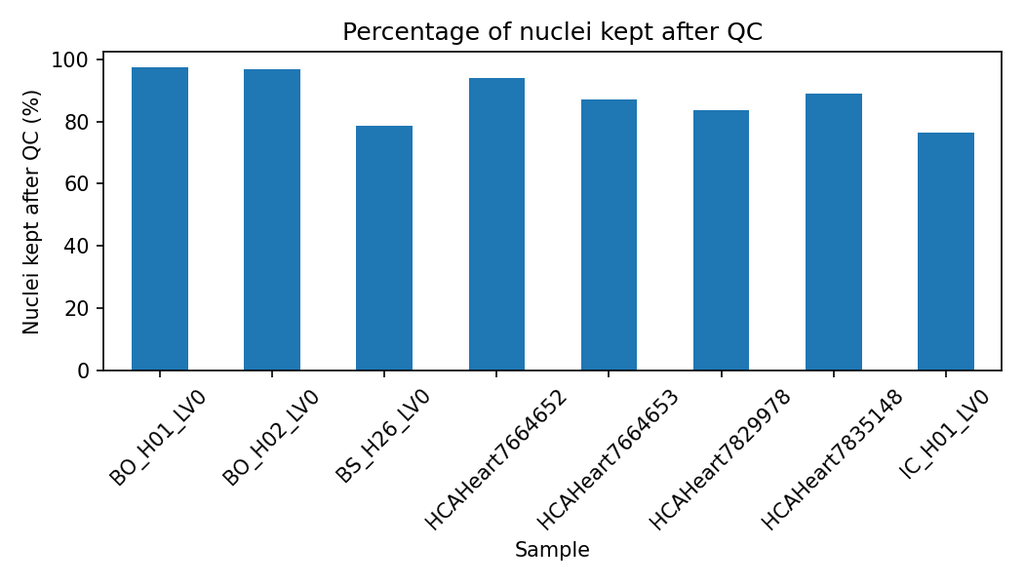

```python
fig, ax = plt.subplots(figsize=(7, 4))

demographics["percent_kept"].plot(kind="bar", ax=ax)

ax.set_xlabel("Sample")
ax.set_ylabel("Nuclei kept after QC (%)")
ax.set_title("Percentage of nuclei kept after QC")
ax.tick_params(axis="x", rotation=45)

fig.tight_layout()
fig.savefig("0003_qc/Task3_percent_kept_by_sample.png", dpi=150)
plt.close(fig)
```

Most samples retain a high proportion of nuclei after QC, suggesting that the filtering steps are not overly aggressive. The lower values for `BS_H26_LV0` and `IC_H01_LV0` indicate that these samples had a larger fraction of nuclei removed by the QC thresholds.

Exit Python:

```python
exit()
```

At the end of this task, we have checked how filtering changed the contribution of each sample to the dataset. This does not yet tell us which cell types are present, but it helps us see whether the filtered dataset is balanced across samples before moving to pseudobulk summaries and later single-nucleus analyses.

## Task 4: Bulklet - creating pseudobulk RNA-seq summaries

Until now, each row of our expression matrix has represented one nucleus. This is the main strength of single-cell and single-nucleus transcriptomics, but it also creates a statistical problem: nuclei from the same biological sample are not independent biological replicates. If one sample contributes thousands of nuclei, we should not treat those nuclei as thousands of independent samples.

A common solution is **pseudobulk analysis**. We sum the raw counts from all retained nuclei belonging to the same sample. The result looks like a small bulk RNA-seq experiment: genes in rows, samples in columns, and integer counts in the table.

In this task, we will create a simple sample-level pseudobulk matrix from the QC-filtered nuclei. Then we will use it in two ways: first for a sample-level `PCA`, and then for a simple tissue-level differential-expression comparison.

**WarningThis is a simplified pseudobulk analysis**

At this point, we have not identified cell types and we have not removed doublets. Therefore, this is a **whole-sample** summary of the retained nuclei, not a cell-type-specific analysis. Later, after cell-type annotation, the same pseudobulk idea can be applied within selected cell types.

Back in the Bash terminal, create the output folder and start Python:

```bash
cd ~/11_scRNAseq
mkdir -p 0004_sample_level
spython
```

Load the libraries for this task:

```python
from pathlib import Path
import warnings

import numpy as np
import pandas as pd
import scanpy as sc

import matplotlib
matplotlib.use("Agg")
import matplotlib.pyplot as plt

from sklearn.decomposition import PCA
from sklearn.preprocessing import StandardScaler

warnings.filterwarnings("ignore", category=UserWarning)

outdir = Path("0004_sample_level")
```

Read the QC-filtered object:

```python
adata = sc.read_h5ad("0003_qc/merged_qc_filtered.h5ad")
adata
```

You should see the filtered object from Task 2, with `39296` nuclei and `27152` genes or features.

Create a simple sample table:

```python
samples = pd.DataFrame(index=sorted(adata.obs["sample"].unique()))
samples.index.name = "sample"

samples["group"] = np.where(
    samples.index.str.startswith("HCAHeart"),
    "control",
    "cardiomyopathy"
)

samples["n_nuclei"] = (
    adata.obs["sample"]
    .value_counts()
    .reindex(samples.index)
    .astype(int)
)

samples
```

You should see one row per sample. For this practical, we use a simplified grouping: `HCAHeart...` samples are treated as `control`, while the other samples are treated as `cardiomyopathy`.

**WarningA simplified grouping**

The original Reichart paper used a richer genotype-stratified design. Here we collapse the samples into two broad groups only to learn the mechanics of pseudobulk analysis. This should not be interpreted as a complete reproduction of the paper.

Aggregate raw counts per sample:

```python
pseudobulk_rows = []

for sample in samples.index:
    one_sample = adata[adata.obs["sample"] == sample]
    summed_counts = np.asarray(one_sample.X.sum(axis=0)).ravel()
    pseudobulk_rows.append(summed_counts)

counts = pd.DataFrame(
    np.vstack(pseudobulk_rows).T,
    index=adata.var_names,
    columns=samples.index
).round().astype(int)

counts.index.name = "gene_id"

counts.shape
```

You should see:

```
(27152, 8)
```

This means that the pseudobulk matrix has `27152` genes or features and `8` samples.

Add sample-level summaries:

```python
samples["library_size"] = counts.sum(axis=0).reindex(samples.index).astype(int)
samples["n_genes_detected"] = (counts > 0).sum(axis=0).reindex(samples.index).astype(int)

samples
```

Save the pseudobulk count matrix and metadata:

```python
genes = adata.var[["gene_symbol"]].copy()
genes.index.name = "gene_id"

counts.to_csv(outdir / "pseudobulk_counts.tsv", sep="\t")
samples.to_csv(outdir / "pseudobulk_samples.tsv", sep="\t")
genes.to_csv(outdir / "pseudobulk_genes.tsv", sep="\t")
```

These three files are the pseudobulk equivalent of a small bulk RNA-seq dataset:

```
pseudobulk_counts.tsv
pseudobulk_samples.tsv
pseudobulk_genes.tsv
```

### 4.1 Sample-level PCA visualisation

A `PCA` gives us a first look at how the samples relate to each other. Here, each point in the plot is one pseudobulk sample, not one nucleus. This connects back to **session 8** (Transcriptomics, Part 2, with **Eszter Ari**), where PCA helped summarise relationships between RNA-seq samples, and to **session 9** (ChIP-seq analysis, with **Marco Trevisan-Herraz**), where clustering and similarity plots helped compare ChIP-seq signal profiles across genomic bins.

Convert the pseudobulk counts to logCPM:

```python
library_size = counts.sum(axis=0)

cpm = counts.divide(library_size, axis=1) * 1_000_000
log_cpm = np.log2(cpm + 1)

log_cpm.to_csv(outdir / "pseudobulk_logCPM.tsv", sep="\t")
```

Select the most variable genes for the PCA:

```python
top_genes = (
    log_cpm.var(axis=1)
    .sort_values(ascending=False)
    .head(2000)
    .index
)

pca_input = log_cpm.loc[top_genes].T
pca_input.shape
```

You should see:

```
(8, 2000)
```

This means that the PCA will use `8` samples and the `2000` most variable genes.

Run the PCA:

```python
scaled = StandardScaler().fit_transform(pca_input)

pca = PCA(n_components=2)
coordinates = pca.fit_transform(scaled)

pca_df = pd.DataFrame(
    coordinates,
    index=pca_input.index,
    columns=["PC1", "PC2"]
)

pca_df = pca_df.join(samples[["group"]])
pca_df["sample"] = pca_df.index

pca_df
```

Save the PCA coordinates:

```python
pca_df.to_csv(outdir / "pseudobulk_pca_scores.tsv", sep="\t", index=False)
```

Create the PCA plot:

```python
fig, ax = plt.subplots(figsize=(6, 5))

for group, group_df in pca_df.groupby("group"):
    ax.scatter(group_df["PC1"], group_df["PC2"], label=group, s=80)

    for _, row in group_df.iterrows():
        ax.text(row["PC1"], row["PC2"], row["sample"], fontsize=8)

ax.axhline(0, linewidth=0.5)
ax.axvline(0, linewidth=0.5)

ax.set_xlabel(f"PC1 ({pca.explained_variance_ratio_[0] * 100:.1f}%)")
ax.set_ylabel(f"PC2 ({pca.explained_variance_ratio_[1] * 100:.1f}%)")
ax.set_title("Pseudobulk PCA")
ax.legend(frameon=False)

fig.tight_layout()
fig.savefig(outdir / "Task4_pseudobulk_pca.png", dpi=150)
plt.close(fig)
```

Once the image has been created, it should look similar to this:

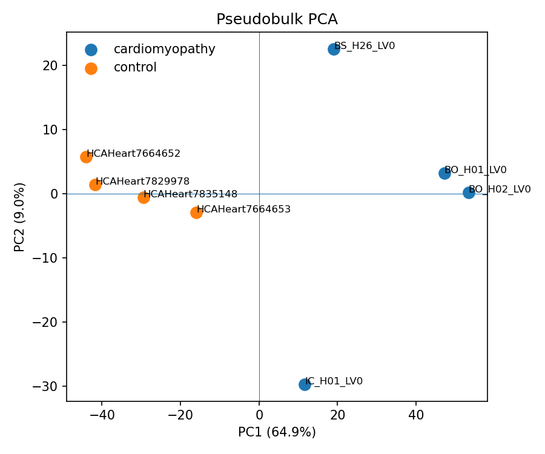

In this PCA, the simplified `control` and `cardiomyopathy` groups separate mainly along `PC1`, which explains `64.9%` of the variance. This means that the largest expression difference between pseudobulk samples is aligned with the left-right axis of the plot. By contrast, `PC2` explains only `9.0%` of the variance, so the vertical differences are smaller overall, even though they still highlight interesting sample-to-sample variation.

The four `HCAHeart...` control samples cluster together on the left, while the cardiomyopathy samples are on the right. However, the cardiomyopathy group is more spread out, especially along `PC2`, with `BS_H26_LV0` and `IC_H01_LV0` appearing as more distinct samples. This is a useful reminder that a two-group label can hide substantial heterogeneity between disease samples.

### 4.2 Tissue-level DESeq2 volcano plot

Now we will run one simple pseudobulk differential-expression comparison: `cardiomyopathy` versus `control`. This is a tissue-level comparison, because all retained nuclei from each sample have been summed together.

Most of you can continue directly, because the variables created in Task 4.1 are still available in the same `spython` session.[^1]

You will remember DESeq2 from **session 8** (Transcriptomics, Part 2, with **Eszter Ari**), where it was used for bulk RNA-seq differential-expression analysis. The key point for today is that `DESeq2` is designed for **integer count data** from biological replicates, which is exactly what we have created with the pseudobulk matrix: genes in rows, samples in columns, and raw summed counts.

Strictly speaking, the original `DESeq2` software is an `R`/Bioconductor package (Love 2014). However, the same count-based differential-expression workflow is also available from Python through `PyDESeq2`, a Python implementation of the DESeq2 method (Muzellec 2023). This fits naturally here because the whole practical is built around a Python/Scanpy workflow. `PyDESeq2` is not the original R package running inside Python; it is a Python implementation designed to make DESeq2-style analysis available in Python-based projects.

Load the DESeq2-style Python interface:

```python
from pydeseq2.dds import DeseqDataSet
from pydeseq2.ds import DeseqStats
```

Filter very weakly detected genes:

```python
gene_keep = (counts >= 10).sum(axis=1) >= 2
counts_de = counts.loc[gene_keep]

counts_de.shape
```

This keeps genes with at least `10` counts in at least `2` samples. The expected output is `(21080, 8)`, which means that `21080` genes remain across `8` pseudobulk samples.

Prepare the count matrix and metadata for DESeq2:

```python
counts_for_deseq = counts_de.T.astype(int)

metadata = samples.loc[counts_for_deseq.index, ["group"]].copy()
metadata["group"] = metadata["group"].astype(str)

metadata
```

**NoteWhy are we using `try` / `except` here?**

Different versions of `PyDESeq2` use slightly different argument names for the experimental design. Recent versions use `design="~group"`, while older versions may expect `design_factors="group"`. The `try` / `except` block below simply tries the newer syntax first and falls back to the older syntax if needed. The statistical model is the same in both cases: expression is modelled as a function of the `group` column.

Run DESeq2:

```python
try:
    dds = DeseqDataSet(
        counts=counts_for_deseq,
        metadata=metadata,
        design="~group",
        quiet=True
    )
except TypeError:
    dds = DeseqDataSet(
        counts=counts_for_deseq,
        metadata=metadata,
        design_factors="group",
        quiet=True
    )

dds.deseq2()
```

This step may take a little longer than the previous commands.

Extract the comparison `cardiomyopathy` versus `control`:

```python
stat_res = DeseqStats(
    dds,
    contrast=["group", "cardiomyopathy", "control"],
    alpha=0.05,
    quiet=True
)

stat_res.summary()

de = stat_res.results_df.copy()
de.index = de.index.astype(str)

gene_symbol_fallback = pd.Series(de.index, index=de.index)

de["gene_symbol"] = (
    genes["gene_symbol"]
    .reindex(de.index)
    .fillna(gene_symbol_fallback)
)

de = de.sort_values("padj", na_position="last")

de[["gene_symbol", "log2FoldChange", "pvalue", "padj"]].head(10)
```

Save the differential-expression table:

```python
de.to_csv(
    outdir / "Task4_pseudobulk_deseq2_cardiomyopathy_vs_control.tsv",
    sep="\t"
)
```

Create a simple volcano plot:

```python
volcano = de.copy()

volcano["minus_log10_padj"] = -np.log10(
    volcano["padj"].fillna(1).clip(lower=1e-300)
)

volcano["significant"] = (
    (volcano["padj"] < 0.05) &
    (volcano["log2FoldChange"].abs() >= 1)
)

fig, ax = plt.subplots(figsize=(6, 5))

nonsig = volcano.loc[~volcano["significant"]].copy()
sig = volcano.loc[volcano["significant"]].copy()

ax.scatter(
    nonsig["log2FoldChange"],
    nonsig["minus_log10_padj"],
    s=8,
    alpha=0.5
)

ax.scatter(
    sig["log2FoldChange"],
    sig["minus_log10_padj"],
    s=8,
    alpha=0.8,
    color="orange"
)

top = volcano.dropna(subset=["padj"]).head(10)

for _, row in top.iterrows():
    ax.text(
        row["log2FoldChange"],
        row["minus_log10_padj"],
        row["gene_symbol"],
        fontsize=7
    )

xmax = np.nanmax(np.abs(volcano["log2FoldChange"].to_numpy()))
xmax = max(1.0, float(np.ceil(xmax)))

ax.set_xlim(-xmax, xmax)

ax.axvline(-1, linewidth=0.5)
ax.axvline(1, linewidth=0.5)
ax.axhline(-np.log10(0.05), linewidth=0.5)

ax.set_xlabel("log2 fold change: cardiomyopathy / control")
ax.set_ylabel("-log10 adjusted p-value")
ax.set_title("Pseudobulk DESeq2 volcano plot")

fig.tight_layout()
fig.savefig(outdir / "Task4_pseudobulk_volcano_cardiomyopathy_vs_control.png", dpi=150)
plt.close(fig)
```

Save a small differential-expression summary:

```python
de_summary = pd.DataFrame([{
    "comparison": "cardiomyopathy_vs_control",
    "genes_tested": int(de.shape[0]),
    "significant_genes_FDR_0.05_log2FC_1": int(volcano["significant"].sum())
}])

de_summary.to_csv(outdir / "Task4_pseudobulk_deseq2_summary.tsv", sep="\t", index=False)

de_summary
```

The volcano plot created above should look similar to this:

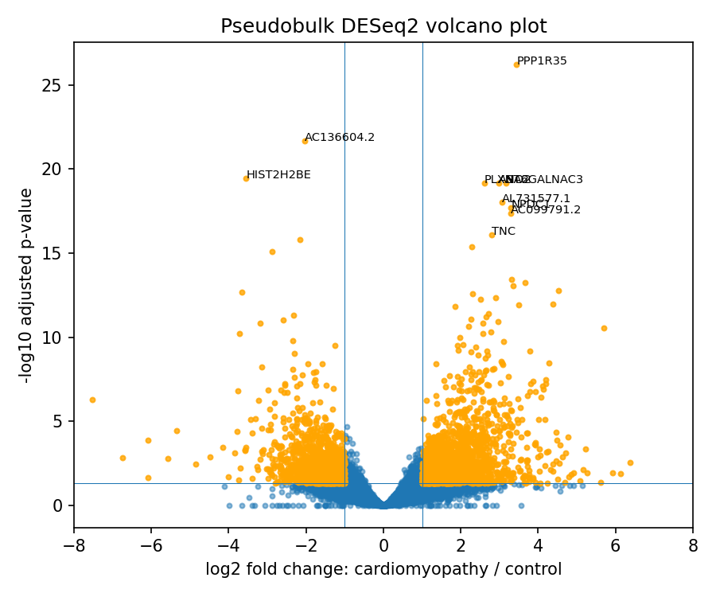

In this volcano plot, each point is one gene. The x-axis shows the `log2` fold change for `cardiomyopathy / control`, so genes on the right are more highly expressed in cardiomyopathy, while genes on the left are more highly expressed in control. The y-axis shows the statistical significance as `-log10` adjusted p-value, so genes higher up have stronger statistical support. Orange points pass our simple threshold: adjusted p-value below `0.05` and absolute `log2` fold change above `1`.

The overall shape is what we expect from a volcano plot: most genes cluster near `log2FC = 0`, while the strongest differential-expression signals appear farther away from the centre and higher on the plot. In this example, there are significant genes on both sides, which means that some genes are higher in cardiomyopathy and others are higher in control. The right-hand side appears slightly richer in highly significant hits, suggesting that, under this simplified grouping, more strong changes may be associated with the cardiomyopathy samples. However, this should be interpreted cautiously, because this is still a simplified analysis and not the full model used in the paper.

Exit Python:

```python
exit()
```

Back in the Bash terminal, check the files produced in this task:

```bash
ls -lh 0004_sample_level
```

You should see files including:

```
pseudobulk_counts.tsv
pseudobulk_samples.tsv
pseudobulk_genes.tsv
pseudobulk_logCPM.tsv
pseudobulk_pca_scores.tsv
Task4_pseudobulk_pca.png
Task4_pseudobulk_deseq2_cardiomyopathy_vs_control.tsv
Task4_pseudobulk_deseq2_summary.tsv
Task4_pseudobulk_volcano_cardiomyopathy_vs_control.png
```

**NoteT4 Q1**

Why do we sum raw counts instead of averaging normalised expression values when creating pseudobulk counts?

**NoteT4 Q2**

In the PCA, do samples separate mainly by the simplified `control` / `cardiomyopathy` grouping, or do some samples look unusual?

**NoteT4 Q3**

Why is pseudobulk differential expression closer to bulk RNA-seq than to cell-by-cell differential expression?

At the end of this task, we have converted the filtered single-nucleus object into a small sample-level pseudobulk dataset. We used it to create a PCA and a simple tissue-level differential-expression volcano plot. This gives us a useful bridge between bulk RNA-seq thinking and the cell-type-aware analyses that will come later.

# Part II: Embedding and clustering single nuclei

Once low-quality nuclei have been removed, and once we have a global view of what is in the dataset, the next challenge is to understand its internal structure. Single-nucleus RNA-seq data are high-dimensional: each nucleus is described by thousands of genes, most of which are sparse and noisy. We therefore need methods that reduce this complexity while preserving enough biological signal to compare nuclei meaningfully.

In this block we will build that representation. The neighbourhood graph, `UMAP`, and clustering are not just technical decorations; they define how we will see the dataset and how we will decide which nuclei are similar. At the same time, these methods can be misleading if artefacts remain. Doublets, for example, may appear as intermediate populations between two real cell types, and clustering parameters can split or merge groups in ways that look biologically convincing but are partly algorithmic.

For that reason, this section should be read as a modelling step rather than a final answer. The aim is to create a useful map of the nuclei, check whether the structure is stable, and prepare a set of clusters that can later be interpreted biologically. The clusters are hypotheses about the data, not yet cell-type identities.

## Task 5: DoubletWatch - identifying and removing doublets

In single-cell and single-nucleus data, a **doublet** is a droplet or partition that contains material from two nuclei instead of one. If we keep them in the dataset, they can look like artificial intermediate populations, mixed clusters, or strange nuclei that appear to express markers from more than one cell type. This can make the downstream `UMAP` and clustering look much more confusing than they really are, and it can also lead us to invent biological explanations for what is actually a technical artefact. The broader lesson is similar to **session 9** (ChIP-seq analysis, with **Marco Trevisan-Herraz**): each assay has its own technical artefacts, and good interpretation depends on recognising them before treating patterns as biology.

The contrast below illustrates the problem.[^2] In one case, the clusters look more fragmented, mixed, and difficult to label; in the other, they look cleaner and easier to interpret. You do not need to understand all the labels yet. The important point is that forgetting doublet removal can make the later steps much harder to interpret.

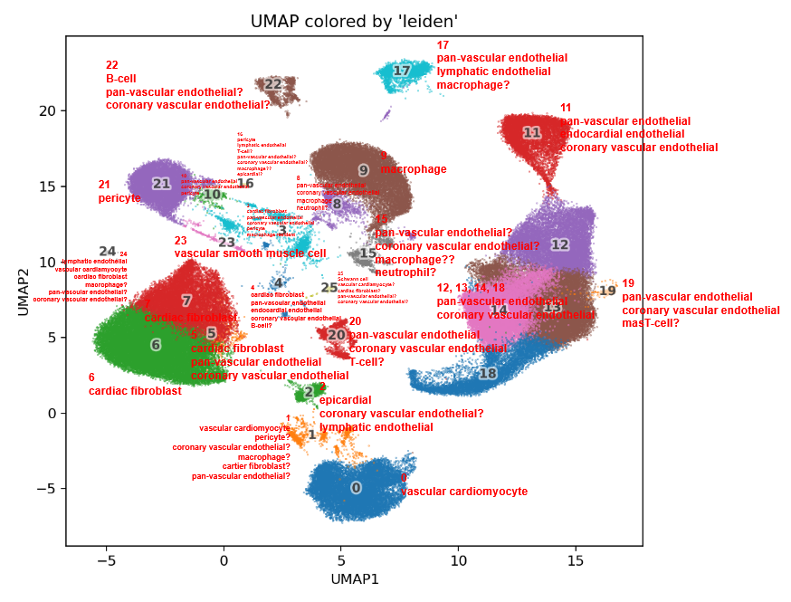

A more confused downstream map when problematic nuclei remain.

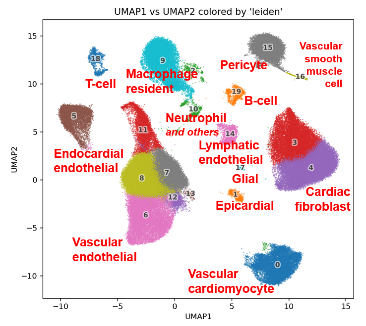

A cleaner downstream map after proper doublet handling.

In this task, we will use `Scrublet` to identify likely doublets (Wolock 2019). We will run it **separately for each sample**, inspect the results, remove the predicted doublets completely, and save a new `.h5ad` file that will be used in Task 6.

The main outputs of this task will be:

```
0005_embedding_clustering/merged_singlets.h5ad
0005_embedding_clustering/Task5_doublet_summary.tsv
0005_embedding_clustering/Task5_percent_doublets_by_sample.png
```

Back in the Bash terminal, make sure the filtered object from Task 2 exists, create the new output folder, and start Python:

```bash
cd ~/11_scRNAseq
ls -lh 0003_qc/merged_qc_filtered.h5ad
spython
```

Load the libraries needed for this task:

```python
from pathlib import Path
import numpy as np
import pandas as pd
import scanpy as sc
import scrublet as scr
import matplotlib.pyplot as plt

outdir = Path("0005_embedding_clustering")
```

Read the QC-filtered object:

```python
adata = sc.read_h5ad("0003_qc/merged_qc_filtered.h5ad")
adata
```

This should reload the object created in Task 2. At this point, we still have one row per nucleus, but we have not yet tried to identify doublets.

Set the parameters that we will use for `Scrublet`:

```python
expected_doublet_rate = 0.06
sim_doublet_ratio = 2.0
n_prin_comps = 30
min_counts = 2
min_cells = 3
min_gene_variability_pctl = 85
```

These are reasonable settings for this dataset. In a real analysis, doublet detection may need more tuning and more diagnostic plots.

Run `Scrublet` **sample by sample**:

```python
adata.obs["doublet_score"] = np.nan
adata.obs["doublet"] = False

reports = []

for sample in sorted(adata.obs["sample"].unique()):
    x = adata[adata.obs["sample"] == sample].copy()
    counts_matrix = x.X.tocsr() if hasattr(x.X, "tocsr") else x.X
    sb = scr.Scrublet(
        counts_matrix,
        expected_doublet_rate=expected_doublet_rate,
        sim_doublet_ratio=sim_doublet_ratio
    )
    scores, calls = sb.scrub_doublets(
        min_counts=min_counts,
        min_cells=min_cells,
        min_gene_variability_pctl=min_gene_variability_pctl,
        n_prin_comps=n_prin_comps
    )
    adata.obs.loc[x.obs_names, "doublet_score"] = scores
    adata.obs.loc[x.obs_names, "doublet"] = calls
    reports.append({
        "sample": sample,
        "n_nuclei": x.n_obs,
        "predicted_doublets": int(calls.sum()),
        "percent_doublets": round(100 * calls.mean(), 2),
        "threshold": round(float(sb.threshold_), 4)
    })
    print(sample, int(calls.sum()), "predicted doublets")
```

You should see one line per sample, followed by the number of nuclei predicted as doublets. The exact numbers may differ slightly depending on the software version and environment, but each sample should produce a result.

Convert the report to a table and inspect it:

```python
doublet_summary = pd.DataFrame(reports)
doublet_summary["singlets_kept"] = (
    doublet_summary["n_nuclei"] - doublet_summary["predicted_doublets"]
)

doublet_summary
```

You should see one row per sample:

```
            sample  n_nuclei  predicted_doublets  percent_doublets  threshold  singlets_kept
0       BO_H01_LV0      5561                  16              0.29     0.6019           5545
1       BO_H02_LV0      6825                 357              5.23     0.1941           6468
2       BS_H26_LV0      6015                 799             13.28     0.1372           5216
3  HCAHeart7664652      4271                  74              1.73     0.3096           4197
4  HCAHeart7664653      3460                 159              4.60     0.1831           3301
5  HCAHeart7829978      4134                  67              1.62     0.3322           4067
6  HCAHeart7835148      5286                 124              2.35     0.2648           5162
7       IC_H01_LV0      3744                 331              8.84     0.1585           3413
```

The percentage of predicted doublets is not identical across samples. For example, `BO_H01_LV0` has very few predicted doublets, while `BS_H26_LV0` and `IC_H01_LV0` have more. This is one reason why we run doublet detection sample by sample rather than applying one global threshold to the whole merged object.

Plot the percentage of predicted doublets for each sample:

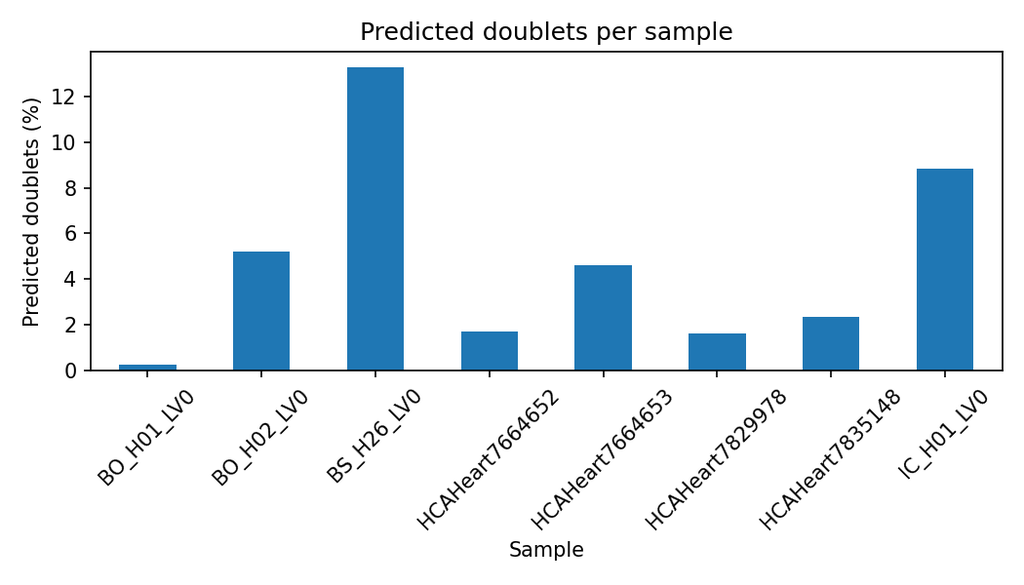

```python
fig, ax = plt.subplots(figsize=(7, 4))

doublet_summary.set_index("sample")["percent_doublets"].plot(kind="bar", ax=ax)

ax.set_xlabel("Sample")
ax.set_ylabel("Predicted doublets (%)")
ax.set_title("Predicted doublets per sample")
ax.tick_params(axis="x", rotation=45)

fig.tight_layout()
fig.savefig(outdir / "Task5_percent_doublets_by_sample.png", dpi=150)
plt.close(fig)
```

The plot highlights that predicted doublet rates vary between samples. `BS_H26_LV0` and `IC_H01_LV0` show the highest predicted doublet percentages, whereas `BO_H01_LV0` has very few predicted doublets. This supports running doublet detection separately for each sample.

Inspect the global number of predicted doublets:

```python
adata.obs["doublet"].value_counts()
```

You should see:

```
doublet
False    37369
True      1927
Name: count, dtype: int64
```

This means that `1927` nuclei are predicted doublets, while `37369` nuclei are predicted singlets and will be kept for the next task.

You can also inspect the first few nuclei:

```python
adata.obs[["sample", "doublet_score", "doublet"]].head()
```

You should see something similar to this:

```
                                   sample  doublet_score  doublet
BO_H01_LV0:AAACCCAAGCTCGCAC-1  BO_H01_LV0       0.027419    False
BO_H01_LV0:AAACCCACACCAAAGG-1  BO_H01_LV0       0.061522    False
BO_H01_LV0:AAACCCACACCCTATC-1  BO_H01_LV0       0.014119    False
BO_H01_LV0:AAACCCACACCGTGCA-1  BO_H01_LV0       0.038658    False
BO_H01_LV0:AAACCCACATCCTCAC-1  BO_H01_LV0       0.325820    False
```

The `doublet_score` is continuous: higher values mean that Scrublet considers the nucleus more doublet-like. The `doublet` column is the final `True` / `False` call that we will use for filtering.

**NoteWhy do we run doublet detection per sample?**

Our object contains several independent samples merged together. The Scrublet documentation recommends running Scrublet separately for each sample when analysing multi-sample data, because Scrublet is designed to detect technical doublets formed by random co-encapsulation, and merged datasets may have cell-type proportions that are not representative of any one sample (Wolock 2024). In other words, doublets should be judged against the background of their own sample.

Remove the predicted doublets completely:

```python
adata_singlets = adata[~adata.obs["doublet"]].copy()
adata_singlets
```

You should see an object with `37369` nuclei:

```
AnnData object with n_obs × n_vars = 37369 × 27152
```

The number of genes or features stays the same, because this step removes nuclei, not genes.

This new object contains only nuclei predicted as singlets. We keep the `doublet_score` and `doublet` columns in `.obs` so that the filtering decision remains documented.

Save the summary table and the singlet-only object:

```python
doublet_summary.to_csv(
    outdir / "Task5_doublet_summary.tsv",
    sep="\t",
    index=False
)

adata_singlets.uns["doublet_params"] = {
    "method": "Scrublet",
    "expected_doublet_rate": expected_doublet_rate,
    "sim_doublet_ratio": sim_doublet_ratio,
    "n_prin_comps": n_prin_comps,
    "min_counts": min_counts,
    "min_cells": min_cells,
    "min_gene_variability_pctl": min_gene_variability_pctl,
    "input": "0003_qc/merged_qc_filtered.h5ad"
}

adata_singlets.write_h5ad(outdir / "merged_singlets.h5ad")
```

Exit Python:

```python
exit()
```

Back in the Bash terminal, check the embedding/clustering output folder:

```bash
ls -lh 0005_embedding_clustering
```

You should see the new singlet-only object and the summary table, including:

```
merged_singlets.h5ad
Task5_doublet_summary.tsv
Task5_percent_doublets_by_sample.png
```

**NoteT5 Q1**

Why can a doublet look like an intermediate or mixed cell population in a downstream `UMAP`?

**NoteT5 Q2**

Why is it useful to save a new singlet-only `.h5ad` file instead of overwriting the earlier QC-filtered object?

At the end of this task, we have removed a major technical artefact that could otherwise distort the structure of the dataset. In the next task, we will build the `UMAP` using the singlet-only object, so that the embedding and clustering are based on cleaner nuclei.

## Task 6: Maploom - building the UMAP embedding

Now we want to see how similar or different the nuclei (or cells) are, and eventually group them by cell type or by cell state. The problem is that each nucleus is described by thousands of genes, that’s too much information. We therefore need **dimensionality reduction** methods: approaches that compress complex gene-expression patterns into fewer dimensions, while keeping as much useful structure as possible. In biosciences (and in general in data analysis), three important dimensionality-reduction methods are `PCA` (Pearson 1901; Hotelling 1933) (which we have seen in Task 4.1), `t-SNE` (van der Maaten 2008), and `UMAP` (McInnes 2018).

In Task 4.1, `PCA` was very useful because each point represented a **whole sample** summarised as a pseudobulk profile. In that context, a simple linear reduction was enough to check whether samples separated in a sensible way. Here, however, we are no longer comparing eight samples: we are comparing **tens of thousands of nuclei**, and the structure of the dataset is much more complex. For this kind of cell-level analysis, `UMAP` is usually more informative than a simple two-dimensional `PCA`, because it can preserve local neighbourhood structure while still giving a readable global map. Compared with `t-SNE`, `UMAP` is often preferred in single-cell work because it tends to scale well, gives more stable-looking global organisation, and has become a standard representation in modern single-cell workflows (Becht 2019).

The three plots below show the **same single-cell RNA-seq dataset** represented with `PCA`, `t-SNE`, and `UMAP`, respectively.[^3] You do not need to understand the cell labels here. The important point is that `PCA` is useful for broad variance summaries, `t-SNE` can separate local groups but may distort the broader structure, and `UMAP` often gives a more convenient overall representation for downstream single-cell interpretation.

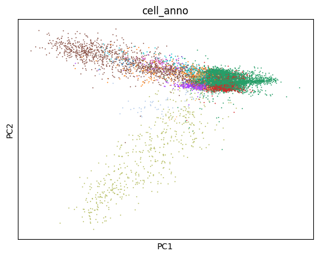

`PCA`

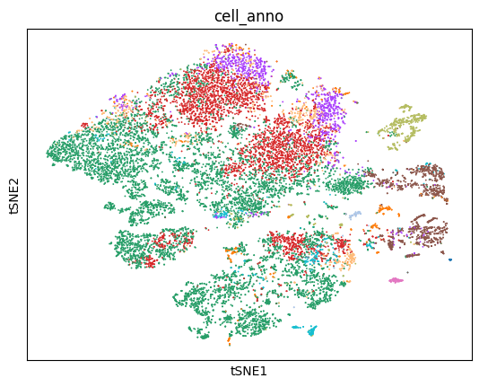

`t-SNE`

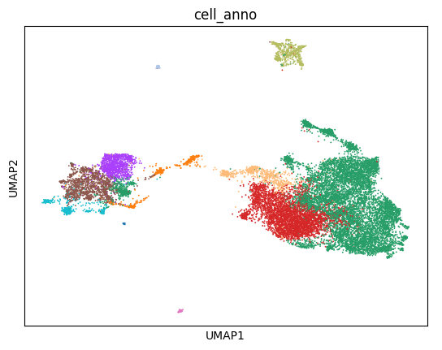

`UMAP`

In this task, we will:

1. start from the singlet-only object created in Task 5,
2. normalise and log-transform the expression matrix,
3. select highly variable genes,
4. compute a `PCA`,
5. build a nearest-neighbour graph,
6. calculate a `UMAP`,
7. save the updated `.h5ad` object, the `UMAP` coordinates, and a simple `UMAP` plot for the following tasks.

The main outputs of this task will be:

```
0005_embedding_clustering/merged_singlets.h5ad
0005_embedding_clustering/Task6_umap_by_sample.png
0005_embedding_clustering/Task6_umap_coordinates.tsv
```

Back in the Bash terminal, go to the working directory and start Python:

```bash
cd ~/11_scRNAseq
spython
```

Load the libraries needed for this task:

```python
from pathlib import Path
import pandas as pd
import scanpy as sc
import matplotlib
matplotlib.use("Agg")
import matplotlib.pyplot as plt

outdir = Path("0005_embedding_clustering")
```

Read the singlet-only object created in Task 5:

```python
adata = sc.read_h5ad(outdir / "merged_singlets.h5ad")
adata
```

This is still a raw-count object, but now it contains only the nuclei that survived both quality control and doublet removal.

Set the main parameters that we will use:

```python
target_sum = 1e4
n_top_genes = 3000
hvg_flavor = "cell_ranger"
n_pcs = 50
n_neighbors = 15
min_dist = 0.5
random_state = 0
```

Before computing the embedding, keep a copy of the raw counts in a layer:

```python
if "counts" not in adata.layers:
    adata.layers["counts"] = adata.X.copy()

adata.X = adata.layers["counts"].copy()
```

Now run the standard preprocessing steps that are commonly used before building a cell-level embedding.[^4] Each step has a specific purpose: normalisation makes nuclei more comparable even if they have different sequencing depths; the log-transform reduces the dominance of very highly expressed genes; highly variable genes focus the analysis on genes that help distinguish nuclei; `PCA` compresses those genes into a smaller set of informative axes; the nearest-neighbour graph defines which nuclei are locally similar; and `UMAP` turns that graph into a two-dimensional map.

We did not do this during QC because normalisation and dimensionality reduction are not filtering decisions. They are modelling steps used to reveal structure after the low-quality nuclei, low-information genes, and likely doublets have already been handled.

When we tested the next block, using the dlab server, the normalisation and PCA took a few seconds, the calculation of the nearest-neighbour graph took around one minute, and the UMAP part took around three minutes. Overall, 4min 30sec.

```python
sc.pp.normalize_total(adata, target_sum=target_sum)
sc.pp.log1p(adata)

sc.pp.highly_variable_genes(
    adata,
    flavor=hvg_flavor,
    n_top_genes=n_top_genes,
    subset=False
)

sc.tl.pca(
    adata,
    n_comps=n_pcs,
    svd_solver="arpack",
    random_state=random_state,
    mask_var="highly_variable"
)

sc.pp.neighbors(
    adata,
    n_neighbors=n_neighbors,
    n_pcs=n_pcs,
    metric="cosine",
    random_state=random_state
)

sc.tl.umap(
    adata,
    min_dist=min_dist,
    init_pos="spectral",
    random_state=random_state
)
```

At this point, the object already contains the reduced representations and graph structure needed for the later clustering task.

You can inspect the first few `UMAP` coordinates:

```python
umap_coords = pd.DataFrame(
    adata.obsm["X_umap"],
    index=adata.obs_names,
    columns=["UMAP1", "UMAP2"]
)

umap_coords.head()
```

You should see two columns, `UMAP1` and `UMAP2`, with one row per nucleus:

```
                                  UMAP1      UMAP2
BO_H01_LV0:AAACCCAAGCTCGCAC-1 -6.599627   2.148598
BO_H01_LV0:AAACCCACACCAAAGG-1  9.081671   1.225129
BO_H01_LV0:AAACCCACACCCTATC-1  0.411984  -5.137094
BO_H01_LV0:AAACCCACACCGTGCA-1 -2.910153  14.620500
BO_H01_LV0:AAACCCACATCCTCAC-1 -4.859608  11.973408
```

Each row is one nucleus, and the two columns are its coordinates in the `UMAP` embedding. The exact numerical values are less important than the neighbourhood structure: nuclei with similar expression profiles should tend to appear close together in the map.

Now plot the embedding coloured by sample:

```python
sc.pl.umap(
    adata,
    color="sample",
    show=False
)

plt.savefig(outdir / "Task6_umap_by_sample.png", dpi=150, bbox_inches="tight")
plt.close()
```

Once the image has been created, it should look similar to this:

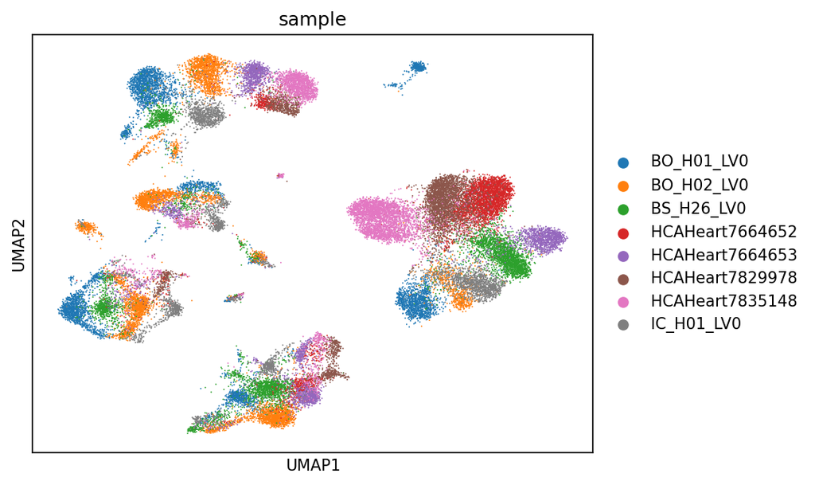

Note that **this `UMAP` is coloured by sample, not by cell type**, because we have not identified cell types yet (that will be done in Task 9). With the current set up, you should have got a graph similar to this one. Can you answer T6 Q3 based on what you see in this graph?

Save the coordinate table and the updated object:

```python
umap_coords.to_csv(
    outdir / "Task6_umap_coordinates.tsv",
    sep="\t"
)

adata.uns["umap_params"] = {
    "target_sum": target_sum,
    "n_top_genes": n_top_genes,
    "hvg_flavor": hvg_flavor,
    "n_pcs": n_pcs,
    "n_neighbors": n_neighbors,
    "min_dist": min_dist,
    "random_state": random_state,
    "input": "0005_embedding_clustering/merged_singlets.h5ad"
}

adata.write_h5ad(outdir / "merged_singlets.h5ad")
```

```python
exit()
```

Back in the Bash terminal, check the files now present in the shared embedding/clustering output folder. This folder also contains outputs from Tasks 5 and 6:

```bash
ls -lh 0005_embedding_clustering
```

[output not shown]

**NoteT6 Q1**

Why was `PCA` a sensible choice in Task 4.1, but not the main final visualisation for tens of thousands of individual nuclei?

**NoteT6 Q2**

Why is it useful to save the updated `.h5ad` object after computing the neighbour graph and the `UMAP`, instead of recomputing everything from the beginning in the next tasks?

**NoteT6 Q3**

Looking at the `UMAP` coloured by sample, do nuclei from different samples mix well within the same regions, or do some areas look dominated by one or a few samples? What could that mean for clustering and cell-type annotation?

At the end of this task, we have created a first low-dimensional representation of the nuclei. Before using it for clustering, we need to ask whether the structure is driven mainly by biology or whether sample-specific effects are still too strong.

## Task 7: Harmonise - correcting strong batch-effects in our datasets

In Task 6, we created a first `UMAP` and coloured it by sample. That plot is useful precisely because it lets us ask whether the embedding is mainly showing biological structure or whether it is strongly influenced by sample identity. If nuclei from the same sample form their own separated islands, then clustering may partly recover samples rather than cell types. This is a common problem in single-cell and single-nucleus analysis: technical variation, library preparation, sequencing depth, sample handling, and biological differences between donors can all affect the structure of the embedding.

There are several ways to deal with this problem. Some methods correct expression values, some correct low-dimensional representations, and some modify the neighbour graph. Common names you may encounter include `Harmony`, `BBKNN`, `Scanorama`, `MNN`, and `scVI`. In this practical, we will use `Harmony`, because it is widely used, computationally efficient, and designed to integrate single-cell datasets by correcting a low-dimensional embedding while preserving biological structure as much as possible (Korsunsky 2019).[^5]

**WarningBatch correction is not magic**

Here we use `sample` as the correction variable because the first `UMAP` suggested strong sample-driven structure. This can make the embedding more useful for clustering and annotation, but it should always be interpreted carefully. If sample identity is strongly linked to real biology, a correction method can also reduce some biological differences. Batch correction helps us build a more interpretable map; it does not prove that all sample differences were technical. Note that in some cases, batch-effects correction is not even needed, everything depends on what the researcher can interpret from the dataset.

The main outputs of this task will be:

```
0005_embedding_clustering/merged_singlets.h5ad
0005_embedding_clustering/Task7_umap_harmony_by_sample.png
0005_embedding_clustering/Task7_umap_harmony_coordinates.tsv
```

Back in the Bash terminal, start a fresh Python session:

```bash
cd ~/11_scRNAseq
spython
```

Load the libraries needed for this task:

```python
from pathlib import Path
import numpy as np
import pandas as pd
import scanpy as sc
import harmonypy as hm
import matplotlib
matplotlib.use("Agg")
import matplotlib.pyplot as plt

outdir = Path("0005_embedding_clustering")
```

Read the singlet-only object created at the end of Task 6. This object already contains the PCA representation that we will use as input for Harmony:

```python
adata_harmony = sc.read_h5ad(outdir / "merged_singlets.h5ad")

if "X_pca" not in adata_harmony.obsm:
    raise ValueError("The object does not contain X_pca. Please complete Task 6 before running Task 7.")

adata_harmony
```

We reload the current singlet object saved at the end of Task 6. It already contains the PCA representation in `adata_harmony.obsm["X_pca"]`, so we do not need to normalise, select highly variable genes, or compute PCA again.

Use the same integration and UMAP parameters as in Task 6:

```python
n_pcs = 50
n_neighbors = 15
min_dist = 0.5
random_state = 0
```

Run Harmony on the `PCA` representation, using `sample` as the correction variable.[^6]

```python
harmony_out = hm.run_harmony(
    adata_harmony.obsm["X_pca"],
    adata_harmony.obs,
    vars_use=["sample"],
    random_state=random_state
)

Z = np.asarray(harmony_out.Z_corr)

if Z.shape[0] == n_pcs:
    Z = Z.T

adata_harmony.obsm["X_pca_harmony"] = Z
adata_harmony.obsm["X_pca_harmony"].shape
```

You should see:

```
(37369, 50)
```

This means that Harmony has produced a corrected `PCA` representation with one row per nucleus and `50` corrected dimensions.

Now build the neighbour graph and calculate the `UMAP` using the Harmony-corrected representation (again, this step took three or four minutes in the course server when we tested it):

```python
sc.pp.neighbors(
    adata_harmony,
    n_neighbors=n_neighbors,
    use_rep="X_pca_harmony",
    metric="cosine",
    random_state=random_state
)

sc.tl.umap(
    adata_harmony,
    min_dist=min_dist,
    init_pos="spectral",
    random_state=random_state
)
```

Create the Harmony-corrected coordinate table:

```python
umap_harmony_coords = pd.DataFrame(
    adata_harmony.obsm["X_umap"],
    index=adata_harmony.obs_names,
    columns=["UMAP1", "UMAP2"]
)

umap_harmony_coords.head()
```

Plot the Harmony-corrected embedding coloured by sample:

```python
sc.pl.umap(
    adata_harmony,
    color="sample",
    show=False
)

plt.savefig(
    outdir / "Task7_umap_harmony_by_sample.png",
    dpi=150,
    bbox_inches="tight"
)

plt.close()
```

Once the image has been created, it should look similar to this:

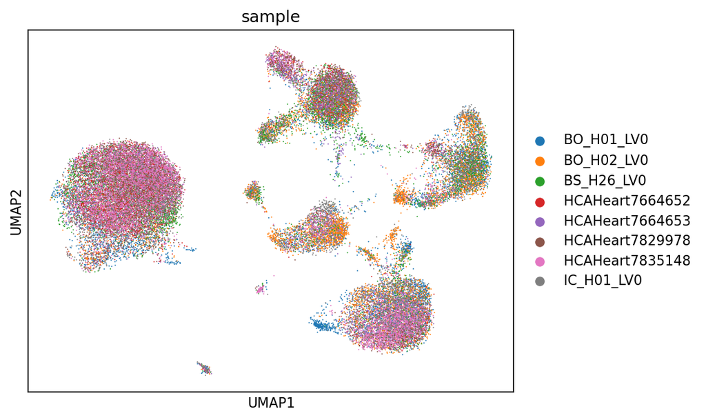

Compared with the Task 6 `UMAP`, the samples are now much better mixed within the same regions of the map. This suggests that the previous embedding was strongly influenced by sample identity. The Harmony-corrected map is therefore more suitable for the next step: clustering nuclei into groups that are more likely to reflect shared transcriptional structure rather than just sample-specific separation. However, the map is not a final biological interpretation yet. We still need clustering and marker genes before we can discuss cell types.

Save the Harmony-corrected coordinates and object:

```python
umap_harmony_coords.to_csv(
    outdir / "Task7_umap_harmony_coordinates.tsv",
    sep="\t"
)

adata_harmony.uns["harmony_params"] = {
    "method": "Harmony",
    "correction_variable": "sample",
    "pca_source": "Task 6 X_pca",
    "n_pcs": n_pcs,
    "n_neighbors": n_neighbors,
    "min_dist": min_dist,
    "random_state": random_state,
    "input": "0005_embedding_clustering/merged_singlets.h5ad"
}

adata_harmony.write_h5ad(
    outdir / "merged_singlets.h5ad"
)
```

Exit Python:

```python
exit()
```

Back in the Bash terminal, check the files produced in this task:

```bash
ls -lh 0005_embedding_clustering
```

You should see files including:

```
merged_singlets.h5ad
Task7_umap_harmony_by_sample.png
Task7_umap_harmony_coordinates.tsv
```

**NoteT7 Q1**

Why can a `UMAP` coloured by sample help us detect sample-driven or batch-driven structure?

**NoteT7 Q2**

Why is it useful to run clustering on the Harmony-corrected representation rather than directly on the first Task 6 embedding?

**NoteT7 Q3**

What is one possible risk of correcting too strongly for sample identity?

At the end of this task, we have created a Harmony-corrected embedding and saved a new `.h5ad` object for the rest of Part II. In the next task, we will use this corrected object to define clusters and compare graph-based clustering methods.

## Task 8: Clusterforge - comparing Louvain and Leiden clusters

After Task 7, each nucleus has a position in a Harmony-corrected `UMAP`, and the object also contains a nearest-neighbour graph. The next question is whether the graph contains groups of nuclei that are more connected to each other than to the rest of the dataset. These groups are what we will call **clusters**. Later, in Task 9, we will ask whether those clusters correspond to known cardiac cell types or cell states.

There are many possible ways to cluster high-dimensional biological data. Some methods, such as `k`-means or hierarchical clustering, group observations using distances in a feature space. In single-cell analysis, however, it is very common to first build a nearest-neighbour graph and then use **community-detection** methods on that graph. In this graph, each nucleus is a node, and edges connect nuclei with similar expression profiles.

`Louvain` and `Leiden` are two related graph-based community-detection algorithms. Both try to find groups of nodes that are more strongly connected internally than expected by chance, often by optimising a modularity-like objective (Blondel 2008; Traag 2019). `Louvain` became popular because it is fast and effective on large graphs. `Leiden` was developed later to fix important limitations of Louvain, especially the possibility of producing poorly connected or even disconnected communities. For that reason, `Leiden` is generally preferred for single-cell clustering, but comparing it with `Louvain` is useful because it shows that cluster definitions depend on algorithmic choices, not only on biology.

In this task, we will use the Harmony-corrected object from Task 7, run `Leiden` clustering, save the updated `.h5ad` object, and generate a `UMAP` coloured by cluster. We will then run `Louvain` on the same object to compare whether the broad structure is similar.

The main outputs of this task will be:

```
0005_embedding_clustering/merged_singlets.h5ad
0005_embedding_clustering/Task8_Leiden_clusters.png
0005_embedding_clustering/Task8_Louvain_clusters.png
```

### 8.1 Clustering with the Leiden algorithm

Back in the Bash terminal, start Python:

```bash
cd ~/11_scRNAseq
spython
```

Load the libraries needed for this task:

```python
from pathlib import Path
import pandas as pd
import scanpy as sc
import matplotlib
matplotlib.use("Agg")
import matplotlib.pyplot as plt

outdir = Path("0005_embedding_clustering")
out_h5ad = outdir / "merged_singlets.h5ad"
```

Read the Harmony-corrected object from Task 7:

```python
adata = sc.read_h5ad(out_h5ad)
adata
```

This object already contains the Harmony-corrected representation, the neighbour graph, and the `UMAP`. We therefore do not need to normalise, run `PCA`, or compute the graph again.

Remove any previous Leiden result and run Leiden clustering. Here, `resolution=1.0` controls the granularity of the clustering: higher values usually produce more clusters, while lower values usually produce fewer clusters.[^7]

```python
adata.obs.drop(columns=["leiden"], errors="ignore", inplace=True)
adata.uns.pop("leiden_colors", None)

sc.tl.leiden(
    adata,
    resolution=1.0,
    key_added="leiden",
    random_state=0,
    flavor="igraph",
    n_iterations=2,
    directed=False
)
```

Inspect the number of nuclei per Leiden cluster:

```python
leiden_counts = (
    adata.obs["leiden"]
    .value_counts()
    .sort_index()
    .rename_axis("leiden")
    .reset_index(name="n_nuclei")
)

leiden_counts
```

You should see one row per Leiden cluster:

```
   leiden  n_nuclei
0       0       814
1       1      4570
2       2      5185
3       3      5661
4       4       174
5       5       109
6       6      2474
7       7      4586
8       8       210
9       9      6792
10     10       543
11     11      3683
12     12       400
13     13       746
14     14       359
15     15       152
16     16       845
17     17        66
```

With `resolution=1.0`, Leiden identifies `18` clusters in this dataset. Some clusters are large, such as clusters `9`, `3`, `2`, `7`, and `1`, while others are much smaller, such as clusters `17`, `5`, and `15`. Small clusters are not automatically wrong, but they should be interpreted carefully in the marker-gene step.

Plot the `UMAP` coloured by Leiden cluster:

```python
sc.pl.umap(
    adata,
    color="leiden",
    legend_loc="on data",
    show=False
)

plt.savefig(
    outdir / "Task8_Leiden_clusters.png",
    dpi=150,
    bbox_inches="tight"
)

plt.close()
```

Once the image has been created, it should look similar to this:

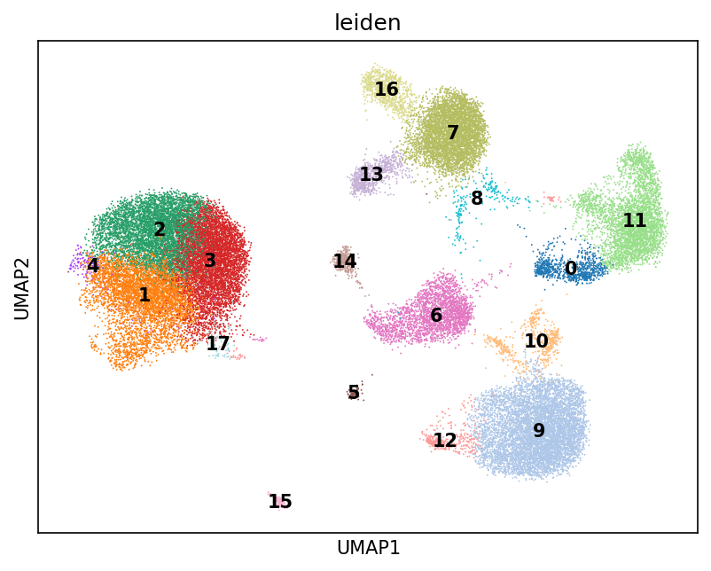

The image shows the Harmony-corrected `UMAP` coloured by Leiden cluster. Several large regions of the map are split into neighbouring clusters, such as the large group on the left and the large group at the bottom right. This is expected: clustering is not simply drawing one boundary around each visual island, but using the nearest-neighbour graph to identify communities of related nuclei.

The cluster numbers are labels assigned by the algorithm. We don’t know which cell-type they are yet. A Leiden cluster may correspond to one broad cell type, a subtype or state within a cell type, or sometimes a technical or ambiguous group. We will interpret the clusters biologically only after looking at marker genes in Task 9.

Save the Leiden cluster counts and overwrite the clustering `.h5ad` file:

```python
leiden_counts.to_csv(
    outdir / "Task8_Leiden_cluster_counts.tsv",
    sep="\t",
    index=False
)

adata.uns["leiden_params"] = {
    "algorithm": "Leiden",
    "resolution": 1.0,
    "random_state": 0,
    "input": "0005_embedding_clustering/merged_singlets.h5ad"
}

adata.write_h5ad(out_h5ad)
```

Keep this Python session open for the next subsection, because we will compare the Leiden result with Louvain using the same object.

### 8.2 Comparing with the Louvain algorithm

Now we will run the related `Louvain` algorithm on the same graph.[^8] This gives us a useful comparison: if the two algorithms produce broadly similar groups, that gives us more confidence in the main structure; if they differ strongly, that tells us that the clustering is sensitive to algorithmic choices.

**WarningIf Louvain is not installed**

On the course server, the required `louvain` package is already installed. If you are running this practical on another machine and get `ModuleNotFoundError: No module named 'louvain'`, install it in the same Python environment used by Scanpy, for example with `python -m pip install louvain`. If you see warnings saying that Louvain has been superseded by `leidenalg`, that is expected: this is exactly why Leiden is the main clustering method in this practical.

Remove any previous Louvain result and run Louvain clustering. Here, we again use `resolution=1.0`, so that the comparison with Leiden is easier to interpret.[^9]

```python
adata.obs.drop(columns=["louvain"], errors="ignore", inplace=True)
adata.uns.pop("louvain_colors", None)

sc.tl.louvain(
    adata,
    resolution=1.0,
    key_added="louvain",
    random_state=0
)
```

Inspect the number of nuclei per Louvain cluster:

```python
louvain_counts = (
    adata.obs["louvain"]
    .value_counts()
    .sort_index()
    .rename_axis("louvain")
    .reset_index(name="n_nuclei")
)

louvain_counts
```

Plot the `UMAP` coloured by Louvain cluster, and then compare it with the Leiden result:

```python
sc.pl.umap(
    adata,
    color="louvain",
    legend_loc="on data",
    show=False
)

plt.savefig(
    outdir / "Task8_Louvain_clusters.png",
    dpi=150,
    bbox_inches="tight"
)

plt.close()
```

Once the image has been created, it should look similar to this:

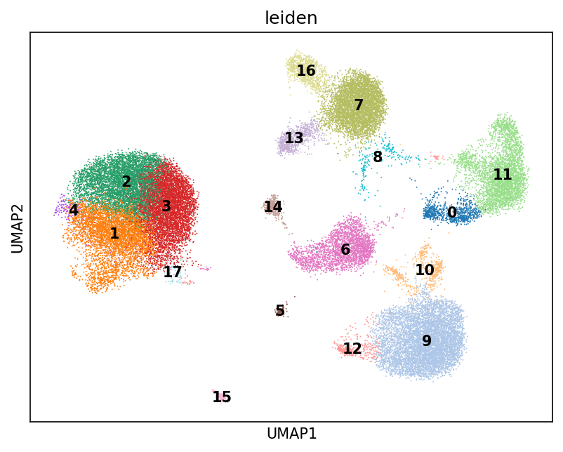

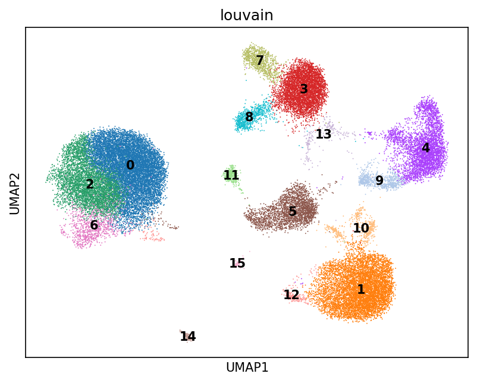

The `Louvain` clusters recover the same broad regions of the `UMAP`, but they do so in a somewhat coarser way. In particular, some large areas that were split into several neighbouring `Leiden` clusters are merged into fewer `Louvain` clusters. This makes the overall map look simpler, but it may also hide some finer structure.

Comparing both results, `Leiden` appears to be the better clustering for this dataset. It preserves the main large regions of the map while also separating smaller neighbouring groups that look transcriptionally distinct in the Harmony-corrected embedding. This is in line with what we would expect: `Leiden` is generally preferred because it tends to produce better-connected and more refined communities than `Louvain` (Traag 2019). In this case, the `Louvain` solution is still useful as a comparison, because it shows that the broad organisation of the dataset is stable, even if some of the finer subdivisions depend on the algorithm used.

If, in another dataset, `Louvain` looked more convincing than `Leiden`, that would not automatically mean that `Louvain` is the better method in general. It could also mean that the `Leiden` clustering was too fine for the chosen resolution, and that the parameters should be revisited. In practice, the best clustering is the one that gives biologically interpretable groups supported by marker genes and downstream analysis.

Save the Louvain cluster counts and overwrite the same clustering `.h5ad` file:

```python
louvain_counts.to_csv(
    outdir / "Task8_Louvain_cluster_counts.tsv",
    sep="\t",
    index=False
)

adata.uns["louvain_params"] = {
    "algorithm": "Louvain",
    "resolution": 1.0,
    "random_state": 0,
    "input": str(out_h5ad)
}

adata.write_h5ad(out_h5ad)
```

Exit Python:

```python
exit()
```

Back in the Bash terminal, check the files now present in the shared embedding/clustering output folder. This folder also contains outputs from Tasks 5, 6, and 7:

```bash
ls -lh 0005_embedding_clustering
```

You should see files including outputs from previous embedding/clustering tasks and the new clustering outputs from Task 8:

```
Task5_doublet_summary.tsv
Task5_percent_doublets_by_sample.png
Task6_umap_by_sample.png
Task6_umap_coordinates.tsv
Task7_umap_harmony_by_sample.png
Task7_umap_harmony_coordinates.tsv
Task8_Leiden_cluster_counts.tsv
Task8_Leiden_clusters.png
Task8_Louvain_cluster_counts.tsv
Task8_Louvain_clusters.png
merged_singlets.h5ad
```

**NoteT8 Q1**

Why do we cluster the nearest-neighbour graph rather than simply drawing boundaries by eye on the `UMAP`?

**NoteT8 Q2**

Why is `Leiden` generally preferred over `Louvain` for graph-based single-cell clustering?

**NoteT8 Q3**

If Leiden and Louvain produce similar broad groups but differ in some small clusters, how would you decide whether those differences are biologically meaningful?

At the end of this task, we have assigned graph-based cluster labels to the Harmony-corrected single-nucleus object. These labels are still only numerical groups. In Task 9, we will use marker genes to ask what biological identities those clusters may represent.

# Part III: Cell-type annotation and differential expression

In this final part of the practical we will do the biological interpretation. Up to this point, the analysis has produced filtered nuclei, low-dimensional coordinates, and clusters. These are useful, but they are not yet the biological result. A cluster number has no meaning by itself unless we can connect it to known cell types, marker genes, and the biological context of the tissue.

This step is especially important in heart `snRNA-seq`, where the tissue contains very different cell populations, including cardiomyocytes, fibroblasts, endothelial cells, immune cells, mural cells, and neuronal cells. A disease signal observed in whole tissue may reflect a true expression change within one cell type, a change in cell-type proportions, or both. Single-nucleus analysis becomes powerful because it lets us separate these possibilities more clearly than bulk RNA-seq.

The aim of this block is therefore to move carefully from clusters to annotations, and then from annotations to cell-type-aware differential expression. Marker genes help us assign biological labels, but the labels should remain evidence-based and revisable. Once cell types have been annotated, differential expression can be asked in a more precise way: not only “what changes in disease?”, but “in which cell population does it change?”.

## Task 9: Cellscribe - marker genes and cell-type labels

This is probably the most subjective, critical, and least algorithmic step of the whole session. Until now, most tasks had a relatively clear input → method → output structure. Cell-type annotation is different. There is no formula that tells us what a cluster *is*. We need to combine marker genes, the `UMAP`, the dot plot, biological knowledge, and caution.

These decisions matter. If we annotate a cluster as `fibroblast`, `cardiomyocyte`, or `immune cell`, later analyses will inherit that decision. A wrong annotation can change the conclusions of a downstream differential-expression analysis. Therefore, the aim of this task is not only to attach labels, but to understand why those labels are defensible.

**NoteCell types are not always the end**

In this practical, we will annotate broad cell types, such as cardiomyocytes, fibroblasts, endothelial cells, immune cells, mural cells, neuronal/glial cells, adipocytes, and mesothelial cells. However, broad cell-type labels can hide important internal diversity. In the Reichart paper, the authors identified not only major cardiac cell types, but also many transcriptional cell states within them (Reichart 2022). These states may reflect stress, activation, remodelling, disease response, or genotype-associated biology. Therefore, a label such as `fibroblast` or `cardiomyocyte` should be understood as a useful first annotation, not necessarily the final biological resolution.

For the practical, we will use a simplified marker table with three representative markers per broad cell type. The table also shows a more specific cell-type context for each marker, but our final annotation will stay at the broad level. From this point on, we will simply call these broad categories `celltype`. The full marker table is also available if you are curious or want to inspect more markers.

```
/shared/OMICS/practical_11/0006_cell_type_annotation/heart_markers_human_short.tsv
/shared/OMICS/practical_11/0006_cell_type_annotation/heart_markers_human.tsv
```

The marker source references are included in the TSV files. For readability, the simplified table below shows only the marker, broad cell type, specific cell type, and comment.

| Marker | Cell type | Specific cell type | Comment |
| --- | --- | --- | --- |
| `TNNT2` | Cardiomyocyte | Core cardiomyocyte | Core sarcomeric cardiomyocyte marker; use with other sarcomeric genes because single markers can be sparse in `snRNA-seq`. |
| `TNNI3` | Cardiomyocyte | Core cardiomyocyte | Cardiac troponin marker; strong support for cardiomyocyte identity when combined with `TNNT2` and `MYH7`/`MYBPC3`. |
| `MYH7` | Cardiomyocyte | Ventricular cardiomyocyte | Ventricular-enriched myosin heavy-chain gene in adult human heart; useful for this ventricular-focused practical. |
| `DCN` | Fibroblast | Core cardiac fibroblast | Strong pan-fibroblast extracellular-matrix marker in human heart; good first marker for fibroblast-rich clusters. |
| `PDGFRA` | Fibroblast | Core cardiac fibroblast | Fibroblast lineage marker; useful with `DCN` and collagen genes while excluding endothelial or cardiomyocyte markers. |
| `COL1A1` | Fibroblast | Core cardiac fibroblast | Collagen/ECM marker; strong in fibroblasts and remodelling states, so interpret with `DCN` and `PDGFRA`. |
| `PECAM1` | Endothelial | Core endothelial | Pan-endothelial marker; best interpreted together with `CDH5` and `VWF`. |
| `CDH5` | Endothelial | Core endothelial | Endothelial junctional marker; strong support for endothelial identity with `PECAM1`/`VWF`. |
| `VWF` | Endothelial | Core endothelial | Endothelial marker with variable expression across subtypes; useful as part of a pan-endothelial panel. |
| `PDGFRB` | Mural cell | Core mural / pericyte and smooth muscle | Broad mural/pericyte marker; interpret with `KCNJ8` for pericytes and `MYH11` for smooth muscle. |
| `KCNJ8` | Mural cell | Pericyte | Pericyte marker in human heart; useful with `PDGFRB` and `ABCC9`. |
| `MYH11` | Mural cell | Vascular smooth muscle cell | Strong vascular smooth-muscle marker; helps distinguish smooth muscle from pericyte-like mural cells. |
| `PTPRC` | Immune cell | Pan-immune / leukocyte | Pan-leukocyte marker; useful as a first broad immune-cell flag, but not informative for immune subtype alone. |
| `C1QA` | Immune cell | Macrophage / myeloid | Macrophage/myeloid marker; useful with `C1QC`, `FOLR2`, or `LYVE1` in the full panel. |
| `CD3D` | Immune cell | T-cell | T-cell marker; included so the short table can flag lymphoid as well as myeloid immune clusters. |
| `MSLN` | Epicardial Mesothelial | Mesothelial / epicardial | Human heart mesothelial marker; rare in adult ventricular `snRNA-seq` and should be interpreted with `WT1`/`BNC1`. |
| `WT1` | Epicardial Mesothelial | Mesothelial / epicardial | Epicardial/mesothelial lineage marker; useful with `MSLN` and `BNC1`, but not sufficient alone. |
| `BNC1` | Epicardial Mesothelial | Mesothelial / epicardial | Mesothelial marker confirmed in adult human heart; useful with `MSLN`/`WT1`. |
| `NRXN1` | Neuronal / Glial | Neuronal cell | Neuronal-associated marker in human heart datasets; neuronal clusters are rare and should be interpreted carefully. |
| `MPZ` | Neuronal / Glial | Schwann-like / myelinating | Schwann-like/myelinating marker in human heart; use with `PRX`/`MBP` in the full panel. |
| `PRX` | Neuronal / Glial | Schwann-like / myelinating | Schwann-like/myelinating marker; supportive marker with `MPZ` and `MBP`. |
| `ADIPOQ` | Adipocyte | Adipocyte | Canonical adipocyte marker; useful if an adipocyte-like cluster appears, but adipocytes may be under-represented in `snRNA-seq`. |
| `PLIN1` | Adipocyte | Adipocyte | Lipid-droplet-associated adipocyte marker; use with `ADIPOQ` and `FABP4` rather than alone. |
| `FABP4` | Adipocyte | Adipocyte | Fatty-acid-binding protein often strong in adipocytes; interpret with `ADIPOQ`/`PLIN1` because it can appear in other contexts. |

The main outputs of this task will be:

```
0006_cell_type_annotation/Task9_marker_dotplot.png
0006_cell_type_annotation/Task9_marker_dotplot_values.tsv
0006_cell_type_annotation/Task9_cluster_to_celltypes.tsv
0006_cell_type_annotation/Task9_umap_celltypes.png
```

We will also overwrite the annotated `.h5ad` file:

```
0005_embedding_clustering/merged_singlets.h5ad
```

### 9.1 Create a marker-gene dot plot

Back in the Bash terminal, start Python:

```bash
cd ~/11_scRNAseq
spython
```

Load the libraries needed for this task:

```python
from pathlib import Path
import numpy as np
import pandas as pd
import scanpy as sc
import matplotlib
matplotlib.use("Agg")
import matplotlib.pyplot as plt
from scipy import sparse

outdir = Path("0006_cell_type_annotation")
input_h5ad = Path("0005_embedding_clustering/merged_singlets.h5ad")

marker_dir = Path("/shared/OMICS/practical_11/0006_cell_type_annotation")
marker_file = marker_dir / "heart_markers_human_short.tsv"
```

Read the clustered object and the simplified marker table:

```python
adata = sc.read_h5ad(input_h5ad)
markers = pd.read_csv(marker_file, sep="\t")

adata
```

Check the marker table:

```python
markers[["Marker_Gene", "Broad_CellType", "Subtype", "Comments"]]
```

Now check which markers are present in the dataset:

```python
marker_genes = markers["Marker_Gene"].tolist()

present_genes = [g for g in marker_genes if g in adata.var_names]
missing_genes = [g for g in marker_genes if g not in adata.var_names]

len(present_genes), missing_genes
```

The output `(24, [])` means that all `24` marker genes from the marker table are present in the dataset, and that the list of missing marker genes is empty. If any marker is missing, it will simply be skipped in the dot plot.

Create a numerical dot-plot table. For each Leiden cluster and each marker gene, we calculate the mean expression and the percentage of nuclei with expression above zero:

```python
cluster_key = "leiden"

clusters = sorted(
    adata.obs[cluster_key].astype(str).unique(),
    key=lambda x: int(x) if x.isdigit() else x
)

X_markers = adata[:, present_genes].X
X_markers = X_markers.tocsr() if sparse.issparse(X_markers) else np.asarray(X_markers)

cluster_labels = adata.obs[cluster_key].astype(str).values
rows = []

for cl in clusters:
    mask = cluster_labels == cl
    n = int(mask.sum())
    sub = X_markers[mask, :]
    if sparse.issparse(sub):
        sums = np.asarray(sub.sum(axis=0)).ravel()
        nnz = sub.getnnz(axis=0)
    else:
        sums = sub.sum(axis=0)
        nnz = (sub > 0).sum(axis=0)
    for gene, mean_expr, pct_expr in zip(present_genes, sums / n, 100 * nnz / n):
        rows.append({
            "leiden": cl,
            "Marker_Gene": gene,
            "mean_expr": mean_expr,
            "pct_expr": pct_expr
        })

dot_values = pd.DataFrame(rows)
dot_values = dot_values.merge(
    markers[["Marker_Gene", "Broad_CellType", "Subtype"]],
    on="Marker_Gene",
    how="left"
)

dot_values.head()
```

Save the numerical dot-plot table:

```python
dot_values.to_csv(
    outdir / "Task9_marker_dotplot_values.tsv",
    sep="\t",
    index=False
)
```

Now create the marker-gene dot plot. Dot size represents the percentage of nuclei in the cluster expressing the marker; dot colour represents mean expression.

```python
marker_dict = (
    markers[markers["Marker_Gene"].isin(present_genes)]
    .groupby("Broad_CellType")["Marker_Gene"]
    .apply(list)
    .to_dict()
)

dotplot = sc.pl.dotplot(
    adata,
    marker_dict,
    groupby="leiden",
    use_raw=False,
    return_fig=True,
    show=False
)

dotplot.savefig(str(outdir / "Task9_marker_dotplot.png"))
plt.close("all")
```

Once the image has been created, it should look similar to this:

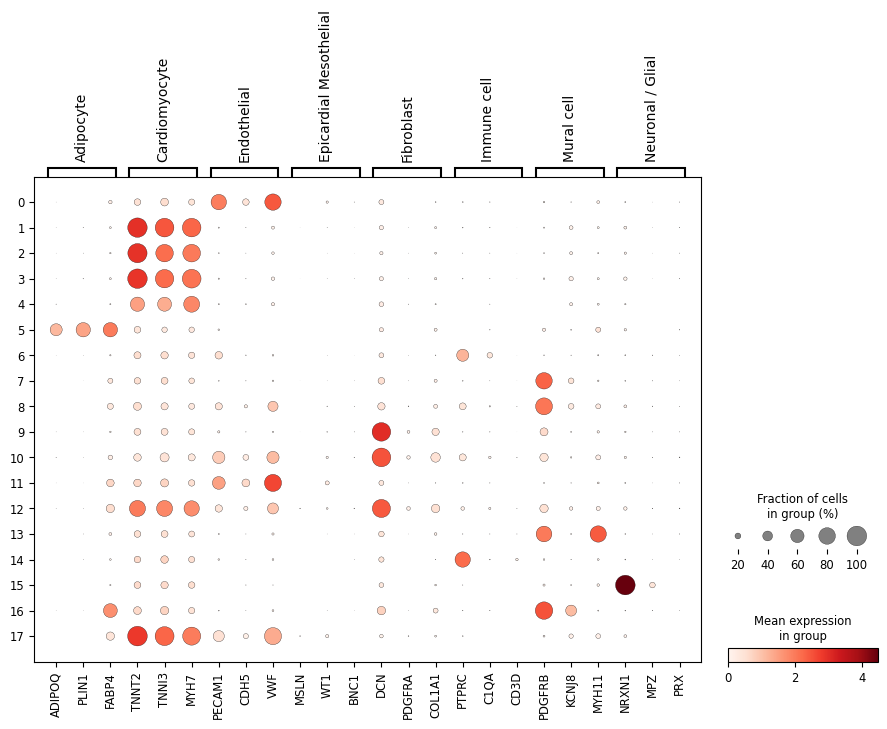

This plot is the first global guide for annotation. We are not assigning labels yet. Instead, we look for clusters where several markers from the same broad cell type agree with each other. A convincing cardiomyocyte cluster, for example, should not depend only on `TNNT2`; it should also show support from other cardiomyocyte markers such as `TNNI3` or `MYH7`.

Several patterns are already visible. Clusters `1`, `2`, `3`, `4`, and `17` show strong cardiomyocyte-marker expression. Cluster `5` is strongly positive for adipocyte markers. Clusters `9`, `10`, and `12` show fibroblast-associated expression, especially `DCN`. Some clusters show endothelial markers such as `PECAM1`, `CDH5`, or `VWF`, while others show mural, immune, or neuronal/glial markers. However, some clusters show partial or mixed signals, so the dot plot should be treated as a guide rather than an automatic annotation table.

Also notice that dot size and dot colour answer different questions. A large pale dot means that many nuclei express the marker at low average level, whereas a small dark dot means that fewer nuclei express it but those that do can have high expression. For annotation, we usually want consistent support from several markers, not just one striking dot.

### 9.2 Inspect individual markers on the UMAP

The dot plot is useful, but it compresses the spatial structure of the data. We also need to inspect individual markers directly on the `UMAP`. First, define a small helper function. After that, we will only need to change the gene name.

```python
def plot_marker_umap(marker_gene):
    if marker_gene not in adata.var_names:
        raise ValueError(f"{marker_gene} is not present in this dataset")
    sc.pl.umap(
        adata,
        color=marker_gene,
        show=False
    )
    ax = plt.gca()
    coords = pd.DataFrame(
        adata.obsm["X_umap"],
        index=adata.obs_names,
        columns=["UMAP1", "UMAP2"]
    )
    coords["leiden"] = adata.obs["leiden"].astype(str).values
    centres = coords.groupby("leiden")[["UMAP1", "UMAP2"]].median()
    for cl, xy in centres.iterrows():
        ax.text(
            xy["UMAP1"],
            xy["UMAP2"],
            cl,
            ha="center",
            va="center",
            fontsize=8,
            bbox={"boxstyle": "round,pad=0.2", "fc": "white", "ec": "none", "alpha": 0.75}
        )
    outfile = outdir / f"Task9_umap_leiden_{marker_gene}.png"
    plt.savefig(
        outfile,
        dpi=150,
        bbox_inches="tight"
    )
    plt.close()
    return outfile
```

```python
plot_marker_umap("TNNT2")
```

Run the second, short block several times, changing only the gene name. For example, try `TNNT2`, `DCN`, `PECAM1`, `PDGFRB`, `PTPRC`, `NRXN1`, and `ADIPOQ`. But don’t limit yourself to this list, explore what you find interesting.

Two example marker `UMAP`s are shown below. We will use them together with the dot plot to decide which Leiden clusters should receive which labels.

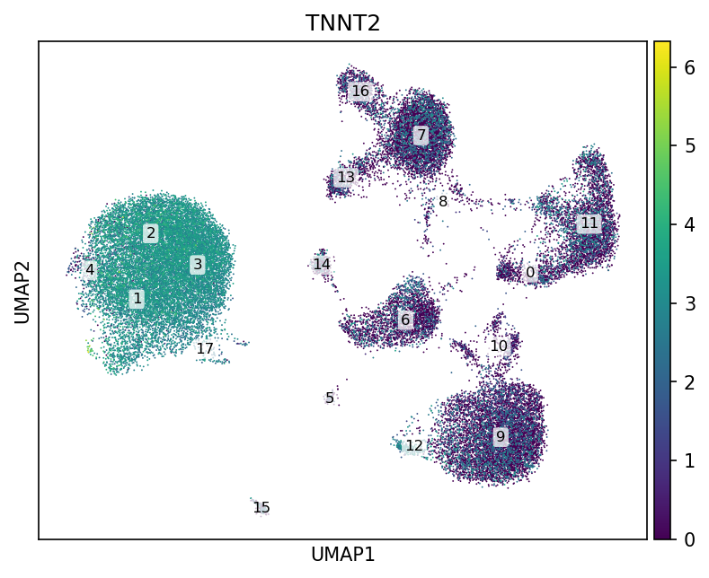

`TNNT2`

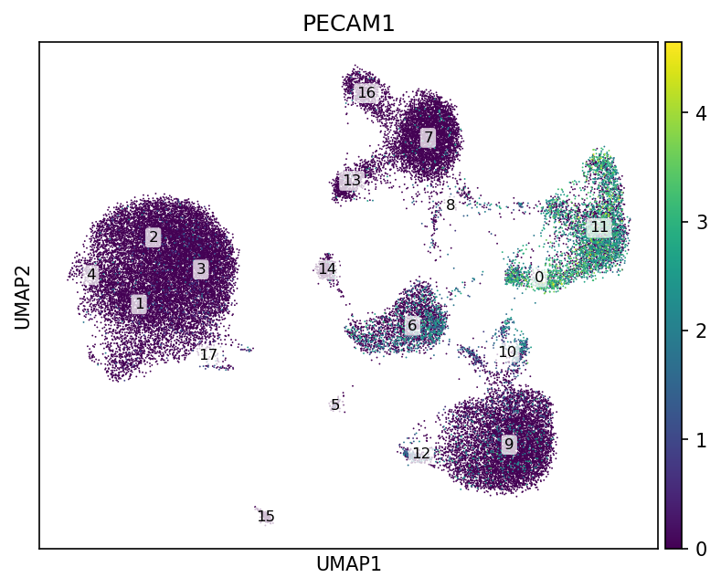

`PECAM1`

### 9.3 Create the cluster-to-cell-type annotation table

Now we create a table that maps each Leiden cluster to a cell type. At first, every cluster is labelled as `unknown`. After inspecting the dot plot and individual marker `UMAP`s, edit the table manually.

```python
cluster_annotation = pd.DataFrame({
    "leiden": clusters,
    "celltype": "unknown"
})

cluster_annotation.to_csv(
    outdir / "Task9_cluster_to_celltypes.tsv",
    sep="\t",
    index=False
)

cluster_annotation
```

Open this file in RStudio or a text editor:

```
0006_cell_type_annotation/Task9_cluster_to_celltypes.tsv
```

Replace `unknown` values with your annotations. For example, a completed row should look like this:

```
leiden    celltype
3         Cardiomyocyte
```

Do not worry if some clusters remain `unknown` or `ambiguous`. That is better than forcing a confident label without enough marker support.

**WarningDo not confuse row numbers with Leiden IDs**

In the RStudio text editor, the numbers shown at the far left are only **editor row numbers**. They are **not** the cluster identifiers. Always annotate clusters using the value in the first column, **`leiden`**. For example, if RStudio shows row `7`, but the first column says `5`, you are annotating **Leiden cluster 5**, not cluster 7.

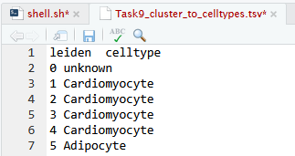

### 9.4 Add cell-type labels to the AnnData object

After editing and saving the annotation table, read it back into Python:

```python
cluster_annotation = pd.read_csv(
    outdir / "Task9_cluster_to_celltypes.tsv",
    sep="\t",
    dtype=str
)

cluster_annotation
```

Now we will assign the cell types we have identified to each nucleus in our dataset (before adding new labels, we will remove any previous cell-type columns):

```python
adata.obs.drop(
    columns=["celltype", "celltype_broad"],
    errors="ignore",
    inplace=True
)

cluster_annotation["leiden"] = cluster_annotation["leiden"].astype(str)

celltype_map = cluster_annotation.set_index("leiden")["celltype"]
leiden_as_text = adata.obs["leiden"].astype(str)

adata.obs["celltype"] = (
    leiden_as_text
    .map(celltype_map)
    .fillna("unknown")
    .astype("category")
)

adata.obs[["leiden", "celltype"]].head()
```

Check how many nuclei are assigned to each label:

```python
adata.obs["celltype"].value_counts()
```

You should see something similar to this:

```
celltype
Cardiomyocyte             15656
Fibroblast                 7335
Mural cell                 6177
Endothelial                4497
Immune cell                2833
ambiguous (cluster 12)      400
ambiguous (cluster 8)       210
Neuronal/glial              152
Adipocyte                   109
Name: count, dtype: int64
```

These numbers depend on the cluster-to-cell-type table that you created manually. If your annotations are slightly different, your counts may also be different. That is fine, as long as the labels are supported by the marker dot plot and the marker `UMAP`s.

### 9.5 Plot the UMAP with cell-type labels

Now plot the same `UMAP`, but coloured by the cell-type labels instead of the numerical Leiden clusters:

```python
sc.pl.umap(
    adata,
    color="celltype",
    legend_loc="right margin",
    show=False
)

plt.savefig(
    outdir / "Task9_umap_celltypes.png",
    dpi=150,
    bbox_inches="tight"
)

plt.close()
```

Once the image has been created, it should look similar to this:

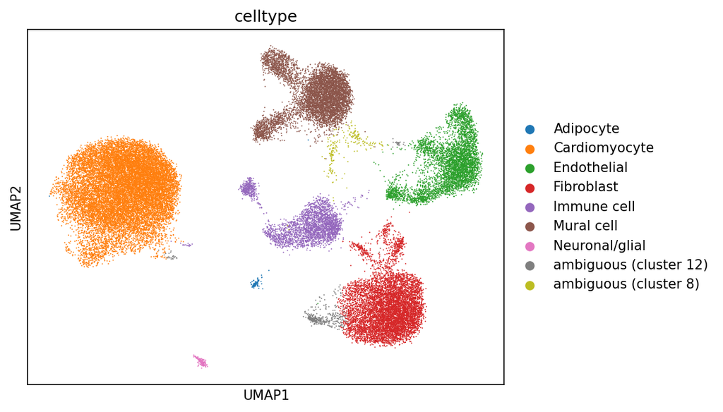

This plot is the first biological version of the map. The numerical Leiden clusters have now been translated into cell-type labels, but the labels should still be treated as working annotations. If a region looks mixed, too broad, or biologically surprising (for example, the case of Cluster 17, here initially identified as cardiomyocytes, but behaving different than other similar cells), the right response is not to force the label, but to go back to the marker dot plot and inspect more genes.

Some cell-types can be split into more specific cell types, for example mural cells consist of two distinct clusters that could be further split into vascular smooth muscle cells and pericytes. This would require going back to the marker genes and interpreting it further.

Save the final annotation table:

```python
final_annotations = (
    adata.obs[["leiden", "celltype"]]
    .drop_duplicates()
    .sort_values("leiden")
)

final_annotations.to_csv(
    outdir / "Task9_final_cluster_annotations.tsv",
    sep="\t",
    index=False
)

final_annotations
```

Finally, overwrite the clustered `.h5ad` object so that Task 10 can use the new `celltype` column:

```python
adata.uns["celltype_annotation"] = {
    "cluster_key": "leiden",
    "annotation_table": "0006_cell_type_annotation/Task9_cluster_to_celltypes.tsv",
    "marker_table": str(marker_file),
    "note": "Manual annotation based on marker dot plot and marker UMAPs"
}

adata.write_h5ad(input_h5ad)
```

You can now exit Python:

```python
exit()
```

Back in the Bash terminal, check the files produced in this task:

```bash
ls -lh 0006_cell_type_annotation
```

You should see files including:

```
Task9_marker_dotplot.png
Task9_marker_dotplot_values.tsv
Task9_cluster_to_celltypes.tsv
Task9_final_cluster_annotations.tsv
Task9_umap_celltypes.png
```

… plus all the `Task9_umap_leiden_<gene>.png` that you have created.

**NoteT9 Q1**

Why is cell-type annotation more subjective than running clustering or calculating a `UMAP`?

**NoteT9 Q2**

Why should we use several marker genes together, rather than assigning a cell type based on one marker alone?

**NoteT9 Q3**

If a cluster expresses markers from two different cell types, what possible explanations should you consider before assigning a final label?

**NoteT9 Q4**

In our marker gene table and in our dot plot we had epicardial mesothelial cells, with gene markers MSLN, WT1 and BNC1. However, in the final table with the cell types they aren’t present. What could be the reason?

At the end of this task, the object contains numerical clusters and working cell-type labels. This means that in Task 10 we can ask differential-expression questions within selected cell types, instead of treating the whole tissue as one mixed sample.

## Task 10: Cellcontrast - DESeq2 within selected cell types

In Task 4, we used pseudobulk differential expression at the **whole-sample** level: all retained nuclei from each sample were summed together, and then we compared `cardiomyopathy` versus `control`. That was useful, but it mixed all cell types together.

Now that Task 9 has added working `celltype` labels, we can ask a more focused question: what changes between `cardiomyopathy` and `control` **within one cell type at a time**?

In this task, we will start with `Cardiomyocyte`. We will:

1. load the annotated `.h5ad` object from Task 9,
2. keep only nuclei labelled as `Cardiomyocyte`,
3. sum raw counts per sample to create a cell-type-specific pseudobulk matrix,
4. run DESeq2-style differential expression with `PyDESeq2`,
5. save the differential-expression tables,
6. create a volcano plot for `cardiomyopathy / control`,
7. repeat the same logic for another cell type, at least `Fibroblast`.

**WarningCell-type-specific pseudobulk still uses samples as replicates**

Even though we are filtering nuclei by cell type, the statistical replicates are still the **samples**, not the individual nuclei. This is why we sum counts per sample before running DESeq2. Treating thousands of nuclei as independent replicates would give artificially overconfident results.

The main outputs of this task will be created in:

```
0007_differential_expression/
```

For `Cardiomyocyte`, the key outputs will include:

```
Task10_pseudobulk_deseq2_cardiomyopathy_vs_control_Cardiomyocyte.tsv
Task10_pseudobulk_deseq2_significant_cardiomyopathy_vs_control_Cardiomyocyte.tsv
Task10_pseudobulk_deseq2_summary_Cardiomyocyte.tsv
Task10_pseudobulk_vplot_Cardiomyocyte.png
```

The same filenames will be created for other cell types by changing the cell-type name.

Back in the Bash terminal, start Python:

```bash
cd ~/11_scRNAseq
spython
```

Load the libraries needed for this task:

```python
from pathlib import Path
import re

import numpy as np
import pandas as pd
import scanpy as sc
from scipy import sparse

import matplotlib
matplotlib.use("Agg")
import matplotlib.pyplot as plt

from pydeseq2.dds import DeseqDataSet
from pydeseq2.ds import DeseqStats

outdir = Path("0007_differential_expression")
outdir.mkdir(exist_ok=True)

input_h5ad = Path("0005_embedding_clustering/merged_singlets.h5ad")
```

Read the annotated object:

```python
adata = sc.read_h5ad(input_h5ad)
adata
```

Check that the columns we need are present:

```python
adata.obs[["sample", "celltype"]].head()
```

The object should contain a `celltype` column from Task 9. We will recreate the simplified `control` / `cardiomyopathy` grouping from the sample names, as we did in Task 4.

Define a helper function for cell-type-specific pseudobulk DESeq2:

```python
def safe_name(x):
    return re.sub(r"[^A-Za-z0-9]+", "_", str(x)).strip("_")

def run_celltype_pseudobulk_de(celltype):
    safe_celltype = safe_name(celltype)
    adata_ct = adata[adata.obs["celltype"].astype(str) == celltype].copy()
    if adata_ct.n_obs == 0:
        raise ValueError(f"No nuclei found for celltype = {celltype}")
    if "counts" not in adata_ct.layers:
        raise ValueError("Raw counts were not found in adata.layers['counts'].")
    samples = pd.DataFrame(index=sorted(adata_ct.obs["sample"].unique()))
    samples.index.name = "sample"
    samples["group"] = np.where(
        samples.index.str.startswith("HCAHeart"),
        "control",
        "cardiomyopathy"
    )
    samples["n_nuclei"] = (
        adata_ct.obs["sample"]
        .value_counts()
        .reindex(samples.index)
        .astype(int)
    )
    X = adata_ct.layers["counts"]
    X = X.tocsr() if sparse.issparse(X) else np.asarray(X)
    pseudobulk_rows = []
    for sample in samples.index:
        idx = np.where(adata_ct.obs["sample"].astype(str).values == sample)[0]
        if sparse.issparse(X):
            summed_counts = np.asarray(X[idx, :].sum(axis=0)).ravel()
        else:
            summed_counts = X[idx, :].sum(axis=0)
        pseudobulk_rows.append(summed_counts)
    counts = pd.DataFrame(
        np.vstack(pseudobulk_rows).T,
        index=adata_ct.var_names.astype(str),
        columns=samples.index
    ).round().astype(int)
    counts.index.name = "gene_id"
    gene_keep = (counts >= 10).sum(axis=1) >= 2
    counts_de = counts.loc[gene_keep]
    counts_for_deseq = counts_de.T.astype(int)
    metadata = samples.loc[counts_for_deseq.index, ["group"]].copy()
    metadata["group"] = metadata["group"].astype(str)
    try:
        dds = DeseqDataSet(
            counts=counts_for_deseq,
            metadata=metadata,
            design="~group",
            quiet=True
        )
    except TypeError:
        dds = DeseqDataSet(
            counts=counts_for_deseq,
            metadata=metadata,
            design_factors="group",
            quiet=True
        )
    dds.deseq2()
    stat_res = DeseqStats(
        dds,
        contrast=["group", "cardiomyopathy", "control"],
        alpha=0.05,
        quiet=True
    )
    stat_res.summary()
    de = stat_res.results_df.copy()
    de.index = de.index.astype(str)
    gene_symbol_fallback = pd.Series(de.index, index=de.index)
    if "gene_symbol" in adata_ct.var.columns:
        de["gene_symbol"] = (
            adata_ct.var["gene_symbol"]
            .reindex(de.index)
            .fillna(gene_symbol_fallback)
        )
    else:
        de["gene_symbol"] = gene_symbol_fallback
    de = de.sort_values("padj", na_position="last")
    de["minus_log10_padj"] = -np.log10(
        de["padj"].fillna(1).clip(lower=1e-300)
    )
    de["significant"] = (
        (de["padj"] < 0.05) &
        (de["log2FoldChange"].abs() >= 1)
    )
    full_table = outdir / f"Task10_pseudobulk_deseq2_cardiomyopathy_vs_control_{safe_celltype}.tsv"
    significant_table = outdir / f"Task10_pseudobulk_deseq2_significant_cardiomyopathy_vs_control_{safe_celltype}.tsv"
    summary_table = outdir / f"Task10_pseudobulk_deseq2_summary_{safe_celltype}.tsv"
    volcano_file = outdir / f"Task10_pseudobulk_vplot_{safe_celltype}.png"
    de.to_csv(full_table, sep="\t")
    de.loc[de["significant"]].to_csv(
        significant_table,
        sep="\t"
    )
    summary = pd.DataFrame([{
        "celltype": celltype,
        "n_nuclei": int(adata_ct.n_obs),
        "n_samples": int(samples.shape[0]),
        "n_control_samples": int((samples["group"] == "control").sum()),
        "n_cardiomyopathy_samples": int((samples["group"] == "cardiomyopathy").sum()),
        "genes_tested": int(de.shape[0]),
        "significant_genes_FDR_0.05_log2FC_1": int(de["significant"].sum()),
        "full_table": str(full_table),
        "significant_table": str(significant_table),
        "volcano_plot": str(volcano_file)
    }])
    summary.to_csv(summary_table, sep="\t", index=False)
    fig, ax = plt.subplots(figsize=(6, 5))
    nonsig = de.loc[~de["significant"]].copy()
    sig = de.loc[de["significant"]].copy()
    ax.scatter(
        nonsig["log2FoldChange"],
        nonsig["minus_log10_padj"],
        s=8,
        alpha=0.5
    )
    ax.scatter(
        sig["log2FoldChange"],
        sig["minus_log10_padj"],
        s=8,
        alpha=0.8,
        color="orange"
    )
    top = de.dropna(subset=["padj"]).head(10)
    for _, row in top.iterrows():
        ax.text(
            row["log2FoldChange"],
            row["minus_log10_padj"],
            row["gene_symbol"],
            fontsize=7
        )
    xmax = np.nanmax(np.abs(de["log2FoldChange"].to_numpy()))
    xmax = max(1.0, float(np.ceil(xmax)))
    ax.set_xlim(-xmax, xmax)
    ax.axvline(-1, linewidth=0.5)
    ax.axvline(1, linewidth=0.5)
    ax.axhline(-np.log10(0.05), linewidth=0.5)
    ax.set_xlabel("log2 fold change: cardiomyopathy / control")
    ax.set_ylabel("-log10 adjusted p-value")
    ax.set_title(f"{celltype}: cardiomyopathy vs control")
    fig.tight_layout()
    fig.savefig(volcano_file, dpi=150)
    plt.close(fig)
    print(f"Finished {celltype}")
    print(summary.to_string(index=False))
    return de, summary
```

This function does the whole workflow for one cell type. The only required input is the cell-type label.

Run the analysis for cardiomyocytes:

```python
de_cardiomyocyte, summary_cardiomyocyte = run_celltype_pseudobulk_de("Cardiomyocyte")
```

Inspect the top rows of the cardiomyocyte differential-expression table:

```python
de_cardiomyocyte.head(10)
```

You should see something similar to this:

```
              baseMean  log2FoldChange     lfcSE       stat        pvalue          padj gene_symbol  minus_log10_padj  significant
gene_id
PPP1R35      88.894873        3.465549  0.338640  10.233739  1.400067e-24  2.521100e-20     PPP1R35         19.598410         True
AC099791.2   68.094888        3.452642  0.348358   9.911182  3.722176e-23  3.351261e-19  AC099791.2         18.474792         True
AL731577.1   52.943577        3.389384  0.357891   9.470425  2.787062e-21  1.672887e-17  AL731577.1         16.776533         True
AC136604.2  309.496274       -2.002763  0.225800  -8.869651  7.337544e-19  3.303179e-15  AC136604.2         14.481068         True
NFE2L3      751.605610       -1.855799  0.215468  -8.612860  7.125983e-18  2.566351e-14      NFE2L3         13.590684         True
EDIL3       429.316061       -2.907578  0.341535  -8.513261  1.691085e-17  5.075228e-14       EDIL3         13.294544         True
AC093110.1  188.539470        3.734687  0.443249   8.425717  3.585475e-17  9.223377e-14  AC093110.1         13.035110         True
HIST2H2BE   197.674516       -2.980407  0.359057  -8.300659  1.035351e-16  2.330446e-13   HIST2H2BE         12.632561         True
USP46-AS1    41.188919        3.381971  0.408960   8.269679  1.343203e-16  2.687451e-13   USP46-AS1         12.570659         True
ZFPM1        95.948381        2.657441  0.327708   8.109179  5.096286e-16  9.117499e-13       ZFPM1         12.040124         True
```

**NoteYour top genes may differ**

These values depend on the cell-type labels created in Task 9. If you annotated one or more Leiden clusters differently, the nuclei included in the `Cardiomyocyte` pseudobulk will change, and the top genes, p-values, and fold changes may also change. That does not automatically mean your analysis is wrong: the important point is that your annotation decisions are supported by the marker plots.

Now **run the same analysis for fibroblasts**, check the volcano plot that is generated, and inspect the top rows of the fibroblast differential-expression table. You can repeat the same analysis for other cell-types.

The volcano plots for cardiomyocytes and fibroblasts should look similar to this:

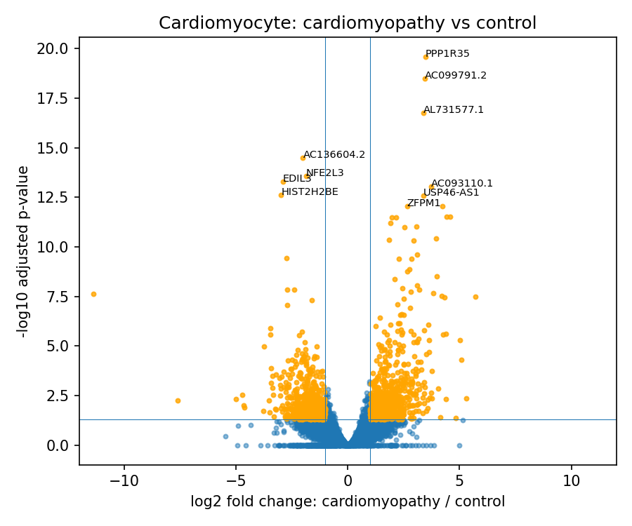

`Cardiomyocyte`

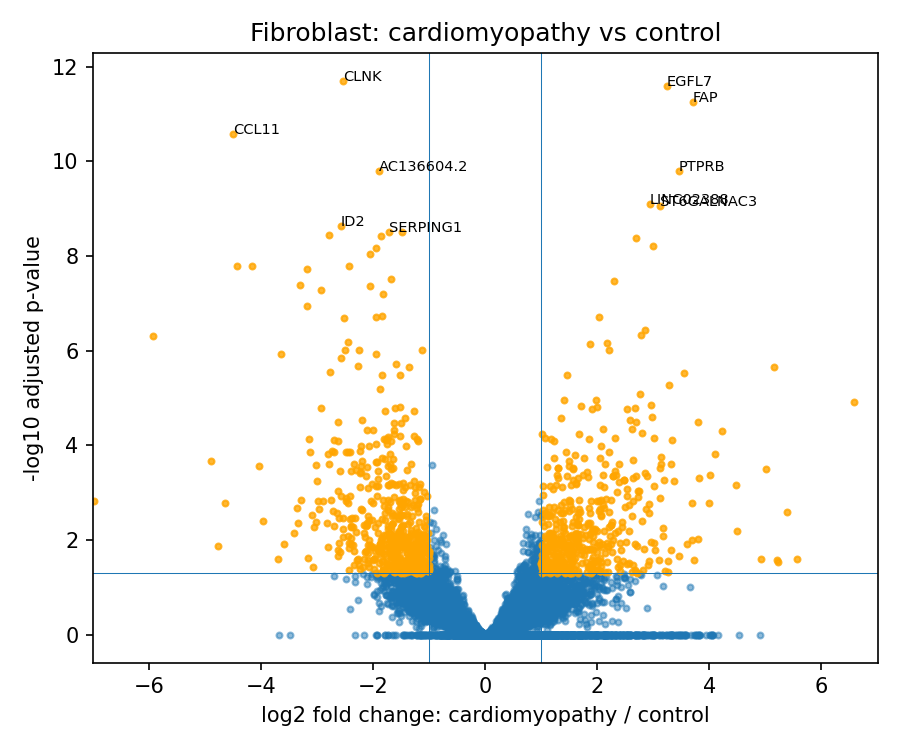

`Fibroblast`

In these volcano plots, each point is one gene tested within the selected cell type. The x-axis shows the `log2` fold change for `cardiomyopathy / control`, so genes on the right are higher in cardiomyopathy and genes on the left are higher in control. The y-axis shows `-log10` adjusted p-value, so genes higher up have stronger statistical evidence. Orange points pass our simple threshold: adjusted p-value below `0.05` and absolute `log2` fold change above `1`.

The cardiomyocyte volcano shows many significant genes on both sides of the plot. Some of the strongest cardiomyopathy-enriched genes in our simplified analysis include `PPP1R35`, `AC099791.2`, `AL731577.1`, `AC093110.1`, `USP46-AS1`, and `ZFPM1`, while genes such as `AC136604.2`, `NFE2L3`, `EDIL3`, and `HIST2H2BE` are higher in controls. These genes should not be over-interpreted one by one in a short practical, especially because several are poorly characterised or non-coding transcripts. However, the overall pattern is useful: cardiomyocytes show a strong disease-associated transcriptional shift. This agrees with the main idea in Reichart 2022, where cardiomyopathy affected cardiomyocyte states and was linked to stress, contractile, metabolic, and electrophysiological programs. The exact top genes are not expected to match perfectly, because the paper analysed genotypes, chambers, and cell states in much more detail, whereas here we are using a simplified `cardiomyopathy` versus `control` comparison within broad cell-type labels (Reichart 2022).

The fibroblast volcano also shows many significant genes, with several cardiomyopathy-enriched genes that fit a remodelling interpretation. For example, `FAP` is a classic activated-fibroblast/remodelling-associated gene, so its position on the cardiomyopathy side is biologically plausible. `EGFL7` and `PTPRB` are more vascular-associated genes, so their appearance in the fibroblast analysis should be interpreted cautiously: they may reflect real fibroblast–vascular signalling, imperfect broad annotation, or nearby mixed/ambiguous nuclei. On the control-enriched side, genes such as `CCL11`, `CLNK`, `ID2`, and `SERPING1` suggest immune/inflammatory or regulatory signals that differ between groups. Reichart 2022 reported that fibrosis was expanded in disease hearts even though fibroblast abundance itself was not simply increased; instead, fibroblasts showed altered transcriptional states, ECM remodelling, TGFβ-related activity, and changes in vFB2/vFB3 states. Our fibroblast result is broadly consistent with that point: disease effects can appear as a change in fibroblast state or activity, not just as more fibroblasts (Reichart 2022).

**WarningDo not treat this as a full reproduction of the paper**

This is a simplified analysis. We are using broad cell-type labels, a small number of samples, a simple `cardiomyopathy` versus `control` grouping, and no explicit modelling of genotype, chamber, sex, age, cell state, or cell-type uncertainty. Therefore, the volcano plots should be read as an illustration of **cell-type-specific pseudobulk logic**, not as a definitive disease model or a direct reproduction of Reichart 2022.

The key difference from Task 4 is that we are no longer asking “what changes in the whole tissue?”. We are asking “what changes in this particular cell type?”. This distinction matters because a whole-tissue signal can reflect true expression changes within a cell type, changes in cell-type abundance, or a mixture of both. Cell-type-specific pseudobulk helps separate these possibilities, but it still depends strongly on the quality of the cell-type annotation from Task 9.

Exit Python:

```python
exit()
```

Back in the Bash terminal, check the files produced in this task:

```bash
ls -lh 0007_differential_expression
```

You should see files including:

```
Task10_pseudobulk_deseq2_cardiomyopathy_vs_control_Cardiomyocyte.tsv
Task10_pseudobulk_deseq2_significant_cardiomyopathy_vs_control_Cardiomyocyte.tsv
Task10_pseudobulk_deseq2_summary_Cardiomyocyte.tsv
Task10_pseudobulk_vplot_Cardiomyocyte.png
Task10_pseudobulk_deseq2_cardiomyopathy_vs_control_Fibroblast.tsv
Task10_pseudobulk_deseq2_significant_cardiomyopathy_vs_control_Fibroblast.tsv
Task10_pseudobulk_deseq2_summary_Fibroblast.tsv
Task10_pseudobulk_vplot_Fibroblast.png
```

**NoteT10 Q1**

Why do we sum counts per sample before running DESeq2, instead of comparing individual nuclei directly?

**NoteT10 Q2**

How can a gene appear differentially expressed in the whole-tissue pseudobulk analysis but not in the cardiomyocyte-only analysis?

**NoteT10 Q3**

Why might the cardiomyocyte and fibroblast volcano plots show different disease-associated genes?

At the end of this task, we have moved from whole-tissue pseudobulk analysis to cell-type-specific pseudobulk analysis. This gives a more focused view of disease-associated transcriptional changes and leaves us with interpretable tables that could be used for downstream biological analysis. In **session 10** (Functional enrichment analysis, with **Eszter Ari**), you used differentially expressed genes for Gene Ontology and pathway-style interpretation; the cell-type-specific tables produced here would be natural inputs for that kind of follow-up.

# Suggested interpretation workflow

If you finish the tasks, try to summarise the whole analysis in the following order:

1. **Metadata and design**: which samples did we analyse, and how did we define `control` and `cardiomyopathy`?
2. **Global sample structure**: does the pseudobulk `PCA` separate samples in a biologically plausible way, and are any samples unusually distant?
3. **Quality control**: did the filtering remove low-quality nuclei and low-information genes without losing entire samples unexpectedly?
4. **Doublet removal**: how many predicted doublets were removed per sample, and did any sample show an unusually high doublet rate?
5. **Batch or sample effects**: did the first `UMAP` show strong sample-driven structure, and did Harmony improve sample mixing?
6. **Cluster interpretation**: do the Leiden clusters form coherent regions of the `UMAP`, and are the broad structures similar to the Louvain comparison?
7. **Marker-gene support**: which clusters have convincing marker-gene evidence for cardiomyocytes, fibroblasts, endothelial cells, mural cells, immune cells, adipocytes, or neuronal/glial cells?
8. **Annotation uncertainty**: which clusters remain ambiguous or mixed, and how could that affect downstream interpretation?
9. **Whole-tissue versus cell-type-specific DE**: which disease-associated signals appear in the whole-tissue pseudobulk analysis, and which ones are clearer within specific cell types?
10. **Biological interpretation**: do the final cell-type-specific differential-expression results support plausible disease biology, while remembering that this is a simplified teaching analysis rather than a full reproduction of the paper?

# What was beyond the scope of this practical

## What we didn’t do today

To keep the practical focused and feasible, we are **not** including the following as core tasks:

Before our tasks:

- raw-read quality control with `FastQC`
- read mapping with `STAR`, `STARsolo`, `Cell Ranger`, or a similar aligner
- cell/nucleus calling from raw droplet data
- rebuilding the complete 10x Genomics output folders

During our tasks:

- formal batch-integration benchmarking

After our tasks:

- full genotype-stratified modelling as performed in the original paper
- `GSEA`, Gene Ontology, or pathway-enrichment analysis as a main endpoint
- ligand-receptor or cell-cell communication modelling
- machine-learning classification of disease genotypes
- spatial transcriptomics, proteomics, or experimental validation

This practical starts from public 10x Genomics `h5` count matrices. These files are already downstream of raw-read processing, barcode handling, alignment, UMI counting, and cell/nucleus calling. Therefore, our focus is not on transforming `FASTQ` files into count matrices, but on understanding what happens after the count matrix exists: importing the data, organising metadata, performing quality control, creating useful representations, clustering nuclei, annotating cell types, and asking focused differential-expression questions.

We are also not running `Cell Ranger` today. `Cell Ranger` is an important and widely used 10x Genomics pipeline, but running it would require raw sequencing files, reference files, more computing time, and a different practical focus. Earlier sessions of this course have already covered read quality, mapping, counting, and bulk RNA-seq analysis, so repeating that logic here would leave less time for the parts that are specific to single-cell and single-nucleus data.

Similarly, we are not making functional enrichment or `GSEA` a main endpoint. Those analyses are useful, but they were already covered in **session 10** (Functional enrichment analysis, with **Eszter Ari**). In this session, differential expression is used mainly to connect cell types, clusters, and disease-associated signals, rather than to build a complete pathway-level interpretation.

## This is only an introduction to single-cell transcriptomics

Single-cell and single-nucleus transcriptomics are fascinating because they let us move from a tissue-level average to a map of many different biological populations. In this practical, we have done the core workflow: importing count matrices, quality control, doublet removal, integration, clustering, annotation, and cell-type-specific pseudobulk differential expression. That is already a lot, but it is still only the beginning of what can be done with an annotated single-cell object.

One natural next step would be to compare disease-associated genes across cell types, asking which responses are shared and which are specific to cardiomyocytes, fibroblasts, endothelial cells, immune cells, or mural cells. Another possibility would be to test whether cardiomyopathy changes cell-type proportions across samples, rather than only changing gene expression within cell types.

A particularly exciting extension would be to study **cell-cell communication**. Tools such as `CellChat` and `CellPhoneDB` use ligand-receptor information to infer possible signalling interactions between annotated cell types (Jin 2021; Efremova 2020). In a heart dataset, this could help ask whether diseased fibroblasts, endothelial cells, immune cells, and cardiomyocytes show altered signalling relationships. These analyses can generate powerful hypotheses, but they require careful interpretation because transcript expression does not prove that a signalling interaction is functional.

Another useful extension would be to re-cluster one broad cell type. For example, after identifying all fibroblasts, one could analyse only fibroblast nuclei again to look for finer fibroblast states. This is closer to what large atlas papers often do: broad cell types are only the first layer, and biologically important disease-associated states may exist inside them.

Some analyses are possible in single-cell transcriptomics but are **not a good fit for this particular practical**. Comparing expression directly between two different cell types, such as cardiomyocytes versus fibroblasts, is usually more useful for marker discovery than for disease differential expression, because different cell types are expected to express different genes by definition. Similarly, differentiation-lineage or trajectory analysis would be fascinating in developmental, regeneration, stem-cell, organoid, tumour-progression, or immune-activation datasets, but it is less appropriate here because adult ventricular nuclei mostly represent mature cell populations rather than a clear differentiation process.

# Optional extension questions

**NoteBonus question 1**

Choose one cluster that was difficult to annotate. Which marker genes support one possible identity, and which marker genes make the annotation uncertain?

**NoteBonus question 2**

Repeat the cell-type-specific pseudobulk analysis for one additional cell type, such as `Mural cell`, `Endothelial`, or `Immune cell`. Does the volcano plot suggest the same disease-associated genes as in cardiomyocytes or fibroblasts?

**NoteBonus question 3**

Compare the whole-tissue pseudobulk result from Task 4 with one cell-type-specific result from Task 10. Can you find a gene that appears important in the whole tissue but is not clearly driven by the selected cell type?

**NoteBonus question 4**

If this were a real research project, which downstream analysis would you run next: pathway enrichment, ligand-receptor analysis, genotype-stratified modelling, or another approach? What extra metadata or validation would you need?

# Quit session

When you are finished, make sure you have exited Python:

```python
exit()
```

If you are still in the Bash terminal and want to close the session cleanly, you can type:

```bash
exit
```

Before closing RStudio Server, check that the main output folders contain the files you want to keep:

```bash
ls -lh 0002_import 0003_qc 0004_sample_level 0005_embedding_clustering 0006_cell_type_annotation 0007_differential_expression
```

The main `.h5ad` files should be limited to the merged raw object, the QC-filtered object, and the final working singlet object.

# References

- Amezquita, Robert A., Aaron T. L. Lun, Etienne Becht, et al. 2020. “Orchestrating Single-Cell Analysis with Bioconductor.” *Nature Methods* 17 (2): 137–145. https://doi.org/10.1038/s41592-019-0654-x.
- Becht, Etienne, Leland McInnes, John Healy, Charles-Antoine Dutertre, Immanuel W. H. Kwok, Lai Guan Ng, Florent Ginhoux, and Evan W. Newell. 2019. “Dimensionality Reduction for Visualizing Single-Cell Data Using UMAP.” *Nature Biotechnology* 37: 38–44. https://doi.org/10.1038/nbt.4314.
- Blondel, Vincent D., Jean-Loup Guillaume, Renaud Lambiotte, and Etienne Lefebvre. 2008. “Fast Unfolding of Communities in Large Networks.” *Journal of Statistical Mechanics: Theory and Experiment* 2008 (10): P10008. https://doi.org/10.1088/1742-5468/2008/10/P10008.
- Efremova, Mirjana, Miquel Vento-Tormo, Sarah A. Teichmann, and Roser Vento-Tormo. 2020. “CellPhoneDB: Inferring Cell-Cell Communication from Combined Expression of Multi-Subunit Ligand-Receptor Complexes.” *Nature Protocols* 15: 1484–1506. https://doi.org/10.1038/s41596-020-0292-x.
- Hotelling, Harold. 1933. “Analysis of a Complex of Statistical Variables into Principal Components.” *Journal of Educational Psychology* 24 (6): 417–441. https://doi.org/10.1037/h0071325.
- Ilicic, Tomislav, Jong Kyoung Kim, Aleksandra A. Kolodziejczyk, Frederik Otzen Bagger, Davis James McCarthy, John C. Marioni, and Sarah A. Teichmann. 2016. “Classification of Low Quality Cells from Single-Cell RNA-seq Data.” *Genome Biology* 17: 29. https://doi.org/10.1186/s13059-016-0888-1.
- Jin, Suoqin, Christian F. Guerrero-Juarez, Lihua Zhang, Ivan Chang, Raul Ramos, Chen-Hsiang Kuan, Peggy Myung, Maksim V. Plikus, and Qing Nie. 2021. “Inference and Analysis of Cell-Cell Communication Using CellChat.” *Nature Communications* 12: 1088. https://doi.org/10.1038/s41467-021-21246-9.
- Korsunsky, Ilya, Nghia Millard, Jean Fan, Kamil Slowikowski, Fan Zhang, Kevin Wei, Yuriy Baglaenko, Michael Brenner, Po-ru Loh, and Soumya Raychaudhuri. 2019. “Fast, Sensitive and Accurate Integration of Single-Cell Data with Harmony.” *Nature Methods* 16: 1289–1296. https://doi.org/10.1038/s41592-019-0619-0.
- Litviňuková, Monika, Carlos Talavera-López, Henrike Maatz, et al. 2020. “Cells of the Adult Human Heart.” *Nature* 588: 466–472. https://doi.org/10.1038/s41586-020-2797-4.
- Love, Michael I., Wolfgang Huber, and Simon Anders. 2014. “Moderated Estimation of Fold Change and Dispersion for RNA-seq Data with DESeq2.” *Genome Biology* 15: 550. https://doi.org/10.1186/s13059-014-0550-8.
- Luecken, Malte D., and Fabian J. Theis. 2019. “Current Best Practices in Single-Cell RNA-seq Analysis: A Tutorial.” *Molecular Systems Biology* 15 (6): e8746. https://doi.org/10.15252/msb.20188746.
- McCarthy, Davis J., Kieran R. Campbell, Aaron T. L. Lun, and Quin F. Wills. 2017. “Scater: Pre-processing, Quality Control, Normalization and Visualization of Single-Cell RNA-seq Data in R.” *Bioinformatics* 33 (8): 1179–1186. https://doi.org/10.1093/bioinformatics/btw777.
- McInnes, Leland, John Healy, and James Melville. 2018. “UMAP: Uniform Manifold Approximation and Projection for Dimension Reduction.” arXiv:1802.03426.
- Muzellec, Boris, Maria Telenczuk, Vincent Cabeli, and Mathieu Andreux. 2023. “PyDESeq2: A Python Package for Bulk RNA-seq Differential Expression Analysis.” *Bioinformatics* 39 (9): btad547. https://doi.org/10.1093/bioinformatics/btad547.
- Pearson, Karl. 1901. “On Lines and Planes of Closest Fit to Systems of Points in Space.” *Philosophical Magazine* 2 (11): 559–572. https://doi.org/10.1080/14786440109462720.
- Reichart, Daniel, Eric L. Lindberg, Henrike Maatz, et al. 2022. “Pathogenic Variants Damage Cell Composition and Single-Cell Transcription in Cardiomyopathies.” *Science* 377: eabo1984. https://doi.org/10.1126/science.abo1984.
- Szabo, Peter A., Hanna Mendes Levitin, Michelle Miron, et al. 2019. “Single-Cell Transcriptomics of Human T Cells Reveals Tissue and Activation Signatures in Health and Disease.” *Nature Communications* 10: 4706. https://doi.org/10.1038/s41467-019-12464-3.
- Traag, V. A., Ludo Waltman, and Nees Jan van Eck. 2019. “From Louvain to Leiden: Guaranteeing Well-Connected Communities.” *Scientific Reports* 9: 5233. https://doi.org/10.1038/s41598-019-41695-z.
- Tucker, Nathan R., Mark Chaffin, Stephen J. Fleming, et al. 2020. “Transcriptional and Cellular Diversity of the Human Heart.” *Circulation* 142 (5): 466–482. https://doi.org/10.1161/CIRCULATIONAHA.119.045401.
- van der Maaten, Laurens, and Geoffrey Hinton. 2008. “Visualizing Data Using t-SNE.” *Journal of Machine Learning Research* 9: 2579–2605.
- Virshup, Isaac, Sergei Rybakov, Fabian J. Theis, Philipp Angerer, and F. Alexander Wolf. 2024. “anndata: Access and Store Annotated Data Matrices.” *Journal of Open Source Software* 9 (101): 4371. https://doi.org/10.21105/joss.04371.
- Wolf, F. Alexander, Philipp Angerer, and Fabian J. Theis. 2018. “SCANPY: Large-Scale Single-Cell Gene Expression Data Analysis.” *Genome Biology* 19: 15. https://doi.org/10.1186/s13059-017-1382-0.
- Wolfien, Markus, Anne-Marie Galow, Paula Müller, et al. 2020. “Single-Nucleus Sequencing of an Entire Mammalian Heart: Cell Type Composition and Velocity.” *Cells* 9 (2): 318. https://doi.org/10.3390/cells9020318.
- Wolock, Samuel L., Romain Lopez, and Allon M. Klein. 2019. “Scrublet: Computational Identification of Cell Doublets in Single-Cell Transcriptomic Data.” *Cell Systems* 8 (4): 281–291.e9. https://doi.org/10.1016/j.cels.2018.11.005.
- Wolock, Samuel L. 2024. “Scrublet: Detect Doublets in Single-Cell RNA-seq Data.” GitHub repository. https://github.com/swolock/scrublet.
- Zheng, Grace X. Y., Jessica M. Terry, Phillip Belgrader, et al. 2017. “Massively Parallel Digital Transcriptional Profiling of Single Cells.” *Nature Communications* 8: 14049. https://doi.org/10.1038/ncomms14049.

## Footnotes

[^1]: If you exited Python after the PCA, or if you get an error such as `NameError: name 'counts' is not defined`, start `spython` again and run this block before continuing with Task 4.2:

    ```python
    from pathlib import Path
    import numpy as np
    import pandas as pd
    import matplotlib
    matplotlib.use("Agg")
    import matplotlib.pyplot as plt

    outdir = Path("0004_sample_level")

    counts = pd.read_csv(outdir / "pseudobulk_counts.tsv", sep="\t", index_col=0)
    samples = pd.read_csv(outdir / "pseudobulk_samples.tsv", sep="\t", index_col=0)
    genes = pd.read_csv(outdir / "pseudobulk_genes.tsv", sep="\t", index_col=0)
    ```

[^2]: These two illustrative `UMAP` examples come from another heart single-cell/single-nucleus study and are shown only to illustrate the general downstream effect of doublet removal. They are **not** derived from the Reichart dataset used in this practical.
[^3]: These three illustrative plots come from another single-cell RNA-seq dataset and are shown only to illustrate the differences between dimensionality-reduction methods. They are **not** derived from the Reichart dataset used in this practical.
[^4]: Here we use the `cell_ranger` highly-variable-gene method because it works in the current environment without requiring extra packages.
[^5]: If you are running this practical on your own computer, you may need to install Harmony support with `pip install harmonypy`. On the course server, `harmonypy` is already installed.
[^6]: Harmony returns the corrected `PCA` matrix as PCs × nuclei in this environment. `AnnData` expects `.obsm` matrices as nuclei × PCs, so we transpose it before storing it as `X_pca_harmony`.
[^7]: Note that the `random_state=0` setting makes the result reproducible for the practical.
[^8]: If you exited Python after section 8.1, start `spython` again and run:

    ```python
    from pathlib import Path
    import pandas as pd
    import scanpy as sc
    import matplotlib
    matplotlib.use("Agg")
    import matplotlib.pyplot as plt

    outdir = Path("0005_embedding_clustering")
    out_h5ad = outdir / "merged_singlets.h5ad"

    adata = sc.read_h5ad(out_h5ad)
    ```

[^9]: As before, `random_state=0` makes the result reproducible for the practical.